# Sales Prediction for Big Mart Outlets

The data scientists at BigMart have collected 2013 sales data for 1559 products across 10 stores in different cities. Also, certain attributes of each product and store have been defined. The aim is to build a predictive model and predict the sales of each product at a particular outlet. Using this model, BigMart will try to understand the properties of products and outlets which play a key role in increasing sales.

# Let's Start !

Let us first import basic libraries

```python
import numpy as np
import pandas as pd
import matplotlib as mpl
import matplotlib.pyplot as plt
import seaborn as sns
import warnings; warnings.filterwarnings(action='once')
plt.style.use('seaborn-whitegrid')
sns.set_style("white")
%matplotlib inline
import missingno
pd.set_option('display.max_columns',None)
```

For integrity purpose , we wont take a look at the testing dataset . We will be dealing with the testing dataset , once we are absolutely done, with our training dataset

```python
datafile = pd.read_csv('train_BigMartSales_AnalyticsVidhya.csv')
```

Looking at the first 5 rows of our datafile

```python
datafile.head()
```

|  | Item_Identifier | Item_Weight | Item_Fat_Content | Item_Visibility | Item_Type | Item_MRP | Outlet_Identifier | Outlet_Establishment_Year | Outlet_Size | Outlet_Location_Type | Outlet_Type | Item_Outlet_Sales |
| --- | --- | --- | --- | --- | --- | --- | --- | --- | --- | --- | --- | --- |
| 0 | FDA15 | 9.30 | Low Fat | 0.016047 | Dairy | 249.8092 | OUT049 | 1999 | Medium | Tier 1 | Supermarket Type1 | 3735.1380 |
| 1 | DRC01 | 5.92 | Regular | 0.019278 | Soft Drinks | 48.2692 | OUT018 | 2009 | Medium | Tier 3 | Supermarket Type2 | 443.4228 |
| 2 | FDN15 | 17.50 | Low Fat | 0.016760 | Meat | 141.6180 | OUT049 | 1999 | Medium | Tier 1 | Supermarket Type1 | 2097.2700 |
| 3 | FDX07 | 19.20 | Regular | 0.000000 | Fruits and Vegetables | 182.0950 | OUT010 | 1998 | NaN | Tier 3 | Grocery Store | 732.3800 |
| 4 | NCD19 | 8.93 | Low Fat | 0.000000 | Household | 53.8614 | OUT013 | 1987 | High | Tier 3 | Supermarket Type1 | 994.7052 |

Looking at the bottom 5 rows of our datafile

```python
datafile.tail()
```

|  | Item_Identifier | Item_Weight | Item_Fat_Content | Item_Visibility | Item_Type | Item_MRP | Outlet_Identifier | Outlet_Establishment_Year | Outlet_Size | Outlet_Location_Type | Outlet_Type | Item_Outlet_Sales |
| --- | --- | --- | --- | --- | --- | --- | --- | --- | --- | --- | --- | --- |
| 8518 | FDF22 | 6.865 | Low Fat | 0.056783 | Snack Foods | 214.5218 | OUT013 | 1987 | High | Tier 3 | Supermarket Type1 | 2778.3834 |
| 8519 | FDS36 | 8.380 | Regular | 0.046982 | Baking Goods | 108.1570 | OUT045 | 2002 | NaN | Tier 2 | Supermarket Type1 | 549.2850 |
| 8520 | NCJ29 | 10.600 | Low Fat | 0.035186 | Health and Hygiene | 85.1224 | OUT035 | 2004 | Small | Tier 2 | Supermarket Type1 | 1193.1136 |
| 8521 | FDN46 | 7.210 | Regular | 0.145221 | Snack Foods | 103.1332 | OUT018 | 2009 | Medium | Tier 3 | Supermarket Type2 | 1845.5976 |
| 8522 | DRG01 | 14.800 | Low Fat | 0.044878 | Soft Drinks | 75.4670 | OUT046 | 1997 | Small | Tier 1 | Supermarket Type1 | 765.6700 |

Extracting the number of null values with respect to each column

```python
datafile.isnull().sum()
```

```
Item_Identifier                 0
Item_Weight                  1463
Item_Fat_Content                0
Item_Visibility                 0
Item_Type                       0
Item_MRP                        0
Outlet_Identifier               0
Outlet_Establishment_Year       0
Outlet_Size                  2410
Outlet_Location_Type            0
Outlet_Type                     0
Item_Outlet_Sales               0
dtype: int64
```

A better visualization !

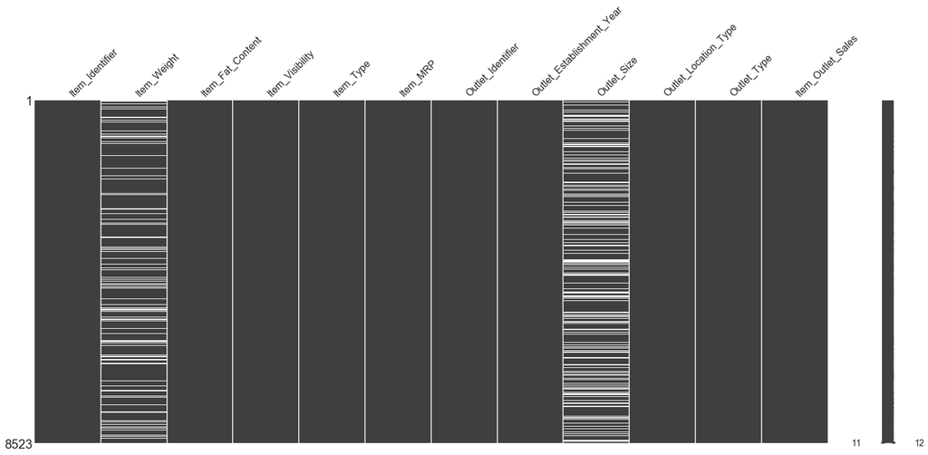

```python
missingno.matrix(datafile)
```

Checking for data types within each attribute

```python
datafile.info()
```

```
<class 'pandas.core.frame.DataFrame'>
RangeIndex: 8523 entries, 0 to 8522
Data columns (total 12 columns):
Item_Identifier              8523 non-null object
Item_Weight                  7060 non-null float64
Item_Fat_Content             8523 non-null object
Item_Visibility              8523 non-null float64
Item_Type                    8523 non-null object
Item_MRP                     8523 non-null float64
Outlet_Identifier            8523 non-null object
Outlet_Establishment_Year    8523 non-null int64
Outlet_Size                  6113 non-null object
Outlet_Location_Type         8523 non-null object
Outlet_Type                  8523 non-null object
Item_Outlet_Sales            8523 non-null float64
dtypes: float64(4), int64(1), object(7)
memory usage: 799.1+ KB
```

Now , let us have a glance at min , max and different percentiles of our continuous attributes

```python
datafile.describe()
```

|  | Item_Weight | Item_Visibility | Item_MRP | Outlet_Establishment_Year | Item_Outlet_Sales |
| --- | --- | --- | --- | --- | --- |
| count | 7060.000000 | 8523.000000 | 8523.000000 | 8523.000000 | 8523.000000 |
| mean | 12.857645 | 0.066132 | 140.992782 | 1997.831867 | 2181.288914 |
| std | 4.643456 | 0.051598 | 62.275067 | 8.371760 | 1706.499616 |
| min | 4.555000 | 0.000000 | 31.290000 | 1985.000000 | 33.290000 |
| 25% | 8.773750 | 0.026989 | 93.826500 | 1987.000000 | 834.247400 |
| 50% | 12.600000 | 0.053931 | 143.012800 | 1999.000000 | 1794.331000 |
| 75% | 16.850000 | 0.094585 | 185.643700 | 2004.000000 | 3101.296400 |
| max | 21.350000 | 0.328391 | 266.888400 | 2009.000000 | 13086.964800 |

Okay ! Looks like Item_Visibility holds a minimum value of 0 which is practically unusual and not so satisfying

Let us look at our categorical values for each attribute

```python
for column in datafile.columns:
    if (len(datafile[column].unique()))<25:
        print(column ,':', len(datafile[column].unique()),':',datafile[column].unique())
```

```
Item_Fat_Content : 5 : ['Low Fat' 'Regular' 'low fat' 'LF' 'reg']
Item_Type : 16 : ['Dairy' 'Soft Drinks' 'Meat' 'Fruits and Vegetables' 'Household'
 'Baking Goods' 'Snack Foods' 'Frozen Foods' 'Breakfast'
 'Health and Hygiene' 'Hard Drinks' 'Canned' 'Breads' 'Starchy Foods'
 'Others' 'Seafood']
Outlet_Identifier : 10 : ['OUT049' 'OUT018' 'OUT010' 'OUT013' 'OUT027' 'OUT045' 'OUT017' 'OUT046'
 'OUT035' 'OUT019']
Outlet_Establishment_Year : 9 : [1999 2009 1998 1987 1985 2002 2007 1997 2004]
Outlet_Size : 4 : ['Medium' nan 'High' 'Small']
Outlet_Location_Type : 3 : ['Tier 1' 'Tier 3' 'Tier 2']
Outlet_Type : 4 : ['Supermarket Type1' 'Supermarket Type2' 'Grocery Store'
 'Supermarket Type3']
```

ALRIGHT ! Lets us create 2 dataframe

1 ) Categorical datafile , consisting of categorical columns

2 ) Continuous datafile , consisting of continuous columns

```python
categorical_datafile=datafile[['Item_Fat_Content',
       'Item_Type', 'Outlet_Identifier',
       'Outlet_Establishment_Year', 'Outlet_Size', 'Outlet_Location_Type',
       'Outlet_Type']]
```

```python
continuous_datafile=datafile[['Item_Weight','Item_Visibility','Item_MRP','Item_Outlet_Sales']]
```

Item Fat Content should orginally be possessed using 2 unique variables , Low Fat and Regular . Although due to difference in human interpretability , low fat / LF / reg were added. Let us just correct that first

```python
datafile['Item_Fat_Content'].replace(['low fat' , 'LF' , 'reg' ] , [ 'Low Fat' , 'Low Fat' , 'Regular' ],inplace=True)
```

We must now look at any correlation (greater than 0.25 and less than -0.25)between continuous attributes

```python
datafile.corr()  >  abs(0.25)
```

|  | Item_Weight | Item_Visibility | Item_MRP | Outlet_Establishment_Year | Item_Outlet_Sales |
| --- | --- | --- | --- | --- | --- |
| Item_Weight | True | False | False | False | False |
| Item_Visibility | False | True | False | False | False |
| Item_MRP | False | False | True | False | True |
| Outlet_Establishment_Year | False | False | False | True | False |
| Item_Outlet_Sales | False | False | True | False | True |

The representation above , implies that there are no strong inter - correlations between features in our datafile

Filling Outlet_Size with Missing , since it is categorical

```python
datafile['Outlet_Size'].fillna('Missing',inplace=True)
```

# Dealing with Missing Values

We observe missing values in the columns : Item_Weight and Outlet_Size . Also , Item_Visibility consists of a good chunk of Zeros 's , which seems impractical , because no Mart would be willing to have any of their Item_Visbility equal to zeros

We shall be dealing with these 3 columns in the following order :

1 ) Item_Weight

2 ) Outlet_Size

3 ) Item_Visibility

```python
datafile['Item_Weight'].describe()
```

```
count    7060.000000
mean       12.857645
std         4.643456
min         4.555000
25%         8.773750
50%        12.600000
75%        16.850000
max        21.350000
Name: Item_Weight, dtype: float64
```

```python
datafile.columns
```

```
Index(['Item_Identifier', 'Item_Weight', 'Item_Fat_Content', 'Item_Visibility',
       'Item_Type', 'Item_MRP', 'Outlet_Identifier',
       'Outlet_Establishment_Year', 'Outlet_Size', 'Outlet_Location_Type',
       'Outlet_Type', 'Item_Outlet_Sales'],
      dtype='object')
```

From now on , I've plotted a number of different graphs based on the intuition that Item_Weight shall have possible dependency on Item_Fat_Content, Item_Type , Item_Identifier , Item_MRP , Item_Visibility .

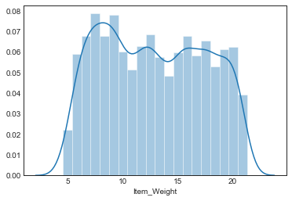

```python
sns.distplot(datafile['Item_Weight'].dropna())
```

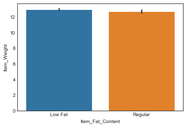

```python
 sns.barplot(x = 'Item_Fat_Content' , y = 'Item_Weight' , data = datafile);
```

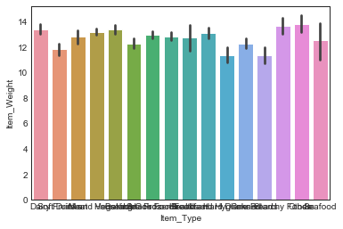

```python
 sns.barplot(x = 'Item_Type' , y = 'Item_Weight' , data = datafile);
```

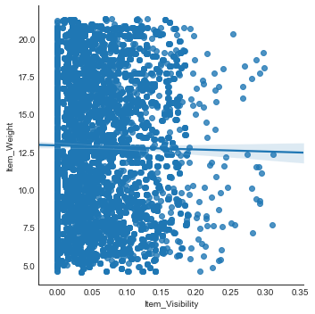

```python
sns.lmplot(x = 'Item_Visibility', y = 'Item_Weight' , data = datafile);
```

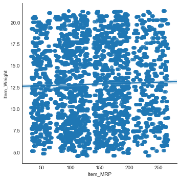

```python
sns.lmplot(x = 'Item_MRP' , y = 'Item_Weight' , data =  datafile);
```

Until now , I am unable to find a foolproof method in order to fill Item_Weight . But we still have one more attribute to help us out and that is Item_Identifier

Also , Item_Identifier might turn out as the strongest attribute when it comes to filling Item_Weight . Because , Item_Identifier is specific to each unique type of item . For example ,looking up against just Item_Type , might lead to wrong assumptions because an apple and a watermelon dont share the same weight. While ,on the other side of the coin , Item Identifier ' FDD08 ' might mean apple , that tends to share similar weight with other apples that eventually have the same Item_Idntifier

```python
datafile[datafile['Item_Identifier'] == 'FDA03']
```

|  | Item_Identifier | Item_Weight | Item_Fat_Content | Item_Visibility | Item_Type | Item_MRP | Outlet_Identifier | Outlet_Establishment_Year | Outlet_Size | Outlet_Location_Type | Outlet_Type | Item_Outlet_Sales |
| --- | --- | --- | --- | --- | --- | --- | --- | --- | --- | --- | --- | --- |
| 11 | FDA03 | 18.5 | Regular | 0.045464 | Dairy | 144.1102 | OUT046 | 1997 | Small | Tier 1 | Supermarket Type1 | 2187.1530 |
| 721 | FDA03 | NaN | Regular | 0.045244 | Dairy | 146.8102 | OUT027 | 1985 | Medium | Tier 3 | Supermarket Type3 | 3499.4448 |
| 747 | FDA03 | 18.5 | Regular | 0.000000 | Dairy | 144.2102 | OUT035 | 2004 | Small | Tier 2 | Supermarket Type1 | 2041.3428 |
| 1951 | FDA03 | 18.5 | Regular | 0.076097 | Dairy | 145.8102 | OUT010 | 1998 | Missing | Tier 3 | Grocery Store | 291.6204 |
| 5772 | FDA03 | 18.5 | Regular | 0.045426 | Dairy | 144.9102 | OUT013 | 1987 | High | Tier 3 | Supermarket Type1 | 1895.5326 |
| 7772 | FDA03 | 18.5 | Regular | 0.045534 | Dairy | 146.3102 | OUT049 | 1999 | Medium | Tier 1 | Supermarket Type1 | 3645.2550 |

```python
datafile[datafile['Item_Identifier'] == 'FDI36']
```

|  | Item_Identifier | Item_Weight | Item_Fat_Content | Item_Visibility | Item_Type | Item_MRP | Outlet_Identifier | Outlet_Establishment_Year | Outlet_Size | Outlet_Location_Type | Outlet_Type | Item_Outlet_Sales |
| --- | --- | --- | --- | --- | --- | --- | --- | --- | --- | --- | --- | --- |
| 5045 | FDI36 | 12.5 | Regular | 0.062343 | Baking Goods | 199.7426 | OUT046 | 1997 | Small | Tier 1 | Supermarket Type1 | 593.2278 |
| 5796 | FDI36 | 12.5 | Regular | 0.062597 | Baking Goods | 196.9426 | OUT018 | 2009 | Medium | Tier 3 | Supermarket Type2 | 5339.0502 |

WUHUU ! We were CORRECT ! So , let us fill the values , right away

```python
datafile['Item_Weight'] = datafile['Item_Weight'].fillna(datafile.groupby('Item_Identifier')['Item_Weight'].transform('median'))
```

```python
datafile[datafile['Item_Weight'].isnull()]
```

|  | Item_Identifier | Item_Weight | Item_Fat_Content | Item_Visibility | Item_Type | Item_MRP | Outlet_Identifier | Outlet_Establishment_Year | Outlet_Size | Outlet_Location_Type | Outlet_Type | Item_Outlet_Sales |
| --- | --- | --- | --- | --- | --- | --- | --- | --- | --- | --- | --- | --- |
| 927 | FDN52 | NaN | Regular | 0.130933 | Frozen Foods | 86.9198 | OUT027 | 1985 | Medium | Tier 3 | Supermarket Type3 | 1569.9564 |
| 1922 | FDK57 | NaN | Low Fat | 0.079904 | Snack Foods | 120.0440 | OUT027 | 1985 | Medium | Tier 3 | Supermarket Type3 | 4434.2280 |
| 4187 | FDE52 | NaN | Regular | 0.029742 | Dairy | 88.9514 | OUT027 | 1985 | Medium | Tier 3 | Supermarket Type3 | 3453.5046 |
| 5022 | FDQ60 | NaN | Regular | 0.191501 | Baking Goods | 121.2098 | OUT019 | 1985 | Small | Tier 1 | Grocery Store | 120.5098 |

We recieved 4 null values , because these Item_Identifiers were unique , therefore , we fill them according to the Item_Type , since its our next best option after Item_Identifier

```python
datafile['Item_Weight'] = datafile['Item_Weight'].fillna(datafile.groupby('Item_Type')['Item_Weight'].transform('mean'))
```

```python
datafile.isnull().sum()
```

```
Item_Identifier              0
Item_Weight                  0
Item_Fat_Content             0
Item_Visibility              0
Item_Type                    0
Item_MRP                     0
Outlet_Identifier            0
Outlet_Establishment_Year    0
Outlet_Size                  0
Outlet_Location_Type         0
Outlet_Type                  0
Item_Outlet_Sales            0
dtype: int64
```

Dont panic , after spotting Zero against Outlet_Size , Remember we filled NaN values with ' Missing '

We shall now deal with Outlet_Size

Once again , as per our intuition , Outlet_Size , would vary with Outlet_Identifier , Outlet_Location_Type , Outlet_Type and Outlet_Sales

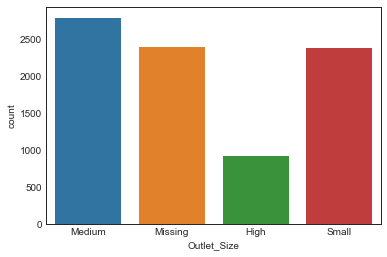

```python
sns.countplot(datafile['Outlet_Size'])
```

```python
pd.crosstab(datafile['Outlet_Size'] , datafile['Outlet_Type'])
```

| Outlet_Type Outlet_Size | Grocery Store | Supermarket Type1 | Supermarket Type2 | Supermarket Type3 |
| --- | --- | --- | --- | --- |
| High | 0 | 932 | 0 | 0 |
| Medium | 0 | 930 | 928 | 935 |
| Missing | 555 | 1855 | 0 | 0 |
| Small | 528 | 1860 | 0 | 0 |

```python
pd.crosstab(datafile['Outlet_Size'] , datafile['Outlet_Location_Type'])
```

| Outlet_Location_Type Outlet_Size | Tier 1 | Tier 2 | Tier 3 |
| --- | --- | --- | --- |
| High | 0 | 0 | 932 |
| Medium | 930 | 0 | 1863 |
| Missing | 0 | 1855 | 555 |
| Small | 1458 | 930 | 0 |

```python
pd.crosstab(datafile['Outlet_Size'] , datafile['Outlet_Identifier'])
```

| Outlet_Identifier Outlet_Size | OUT010 | OUT013 | OUT017 | OUT018 | OUT019 | OUT027 | OUT035 | OUT045 | OUT046 | OUT049 |
| --- | --- | --- | --- | --- | --- | --- | --- | --- | --- | --- |
| High | 0 | 932 | 0 | 0 | 0 | 0 | 0 | 0 | 0 | 0 |
| Medium | 0 | 0 | 0 | 928 | 0 | 935 | 0 | 0 | 0 | 930 |
| Missing | 555 | 0 | 926 | 0 | 0 | 0 | 0 | 929 | 0 | 0 |
| Small | 0 | 0 | 0 | 0 | 528 | 0 | 930 | 0 | 930 | 0 |

Until now , there are 2 possibilites :

1 ) Treat Missing Outlet_Size as a different categorical variable all together , because it has unique outlets

2 ) Treat Missing Outlet_Size by taking mode with respect to each Outlet_Type(indirectly , treat them as 'Small' because Small dominates in each and every Outlet_Size)

To help us decide between these 2 possibilities we plot the following graph

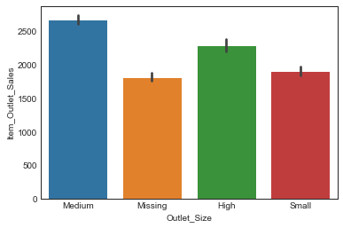

```python
sns.barplot(x='Outlet_Size' , y='Item_Outlet_Sales' , data=datafile)
```

Missing OUtlet_Size have similar Sales as Small Outlet_Size . Therefore we go ahead with ' Small '

```python
datafile['Outlet_Size'].replace(to_replace = 'Missing' , value = 'Small' ,  inplace=True)
```

Time to treat those naughty Zeros relaxing in Item_Visibility

As per our correlation representation before , Item_Visibility shows no relation with any od the continuous attributes . Item_Visibility might have a realtion with Outlet_Size , Outlet_Type , Item_Type , Item_Identifier .

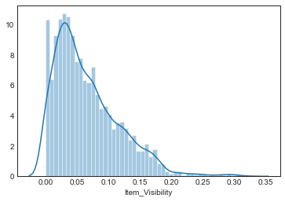

```python
sns.distplot(datafile['Item_Visibility'])
```

```python
datafile['Item_Visibility'].describe()
```

```
count    8523.000000
mean        0.066132
std         0.051598
min         0.000000
25%         0.026989
50%         0.053931
75%         0.094585
max         0.328391
Name: Item_Visibility, dtype: float64
```

```python
datafile.pivot_table(values = 'Item_Visibility' , index = 'Item_Identifier').head()
```

| Item_Identifier | Item_Visibility |
| --- | --- |
| DRA12 | 0.031956 |
| DRA24 | 0.048062 |
| DRA59 | 0.134718 |
| DRB01 | 0.082126 |
| DRB13 | 0.008002 |

```python
datafile.pivot_table(values = 'Item_Visibility', index = 'Item_Type').head()
```

| Item_Type | Item_Visibility |
| --- | --- |
| Baking Goods | 0.069169 |
| Breads | 0.066255 |
| Breakfast | 0.085723 |
| Canned | 0.068129 |
| Dairy | 0.072427 |

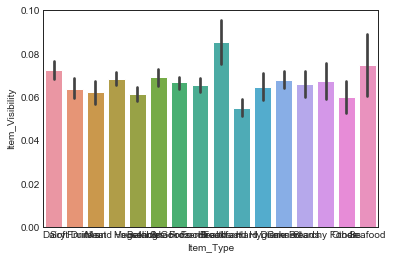

```python
sns.barplot(x = 'Item_Type' , y = 'Item_Visibility' , data = datafile)
```

```python
datafile[datafile['Item_Identifier'] == 'DRA12']
```

|  | Item_Identifier | Item_Weight | Item_Fat_Content | Item_Visibility | Item_Type | Item_MRP | Outlet_Identifier | Outlet_Establishment_Year | Outlet_Size | Outlet_Location_Type | Outlet_Type | Item_Outlet_Sales |
| --- | --- | --- | --- | --- | --- | --- | --- | --- | --- | --- | --- | --- |
| 118 | DRA12 | 11.6 | Low Fat | 0.041178 | Soft Drinks | 140.3154 | OUT017 | 2007 | Small | Tier 2 | Supermarket Type1 | 2552.6772 |
| 1197 | DRA12 | 11.6 | Low Fat | 0.000000 | Soft Drinks | 141.6154 | OUT045 | 2002 | Small | Tier 2 | Supermarket Type1 | 3829.0158 |
| 1245 | DRA12 | 11.6 | Low Fat | 0.040912 | Soft Drinks | 142.3154 | OUT013 | 1987 | High | Tier 3 | Supermarket Type1 | 2552.6772 |
| 1693 | DRA12 | 11.6 | Low Fat | 0.000000 | Soft Drinks | 141.9154 | OUT035 | 2004 | Small | Tier 2 | Supermarket Type1 | 992.7078 |
| 7467 | DRA12 | 11.6 | Low Fat | 0.041113 | Soft Drinks | 142.0154 | OUT018 | 2009 | Medium | Tier 3 | Supermarket Type2 | 850.8924 |
| 8043 | DRA12 | 11.6 | Low Fat | 0.068535 | Soft Drinks | 143.0154 | OUT010 | 1998 | Small | Tier 3 | Grocery Store | 283.6308 |

```python
datafile[datafile['Item_Identifier'] == 'NCZ54']
```

|  | Item_Identifier | Item_Weight | Item_Fat_Content | Item_Visibility | Item_Type | Item_MRP | Outlet_Identifier | Outlet_Establishment_Year | Outlet_Size | Outlet_Location_Type | Outlet_Type | Item_Outlet_Sales |
| --- | --- | --- | --- | --- | --- | --- | --- | --- | --- | --- | --- | --- |
| 214 | NCZ54 | 14.65 | Low Fat | 0.000000 | Household | 161.5552 | OUT010 | 1998 | Small | Tier 3 | Grocery Store | 324.9104 |
| 1896 | NCZ54 | 14.65 | Low Fat | 0.082956 | Household | 164.0552 | OUT027 | 1985 | Medium | Tier 3 | Supermarket Type3 | 5523.4768 |
| 1969 | NCZ54 | 14.65 | Low Fat | 0.083528 | Household | 162.4552 | OUT045 | 2002 | Small | Tier 2 | Supermarket Type1 | 2274.3728 |
| 2839 | NCZ54 | 14.65 | Low Fat | 0.083359 | Household | 161.9552 | OUT046 | 1997 | Small | Tier 1 | Supermarket Type1 | 4711.2008 |
| 7166 | NCZ54 | 14.65 | Low Fat | 0.145952 | Household | 160.9552 | OUT019 | 1985 | Small | Tier 1 | Grocery Store | 162.4552 |
| 7738 | NCZ54 | 14.65 | Low Fat | 0.083699 | Household | 163.4552 | OUT018 | 2009 | Medium | Tier 3 | Supermarket Type2 | 2599.2832 |
| 7926 | NCZ54 | 14.65 | Low Fat | 0.083489 | Household | 161.3552 | OUT049 | 1999 | Medium | Tier 1 | Supermarket Type1 | 7148.0288 |

```python
datafile[datafile['Item_Identifier'] == 'FDX07']
```

|  | Item_Identifier | Item_Weight | Item_Fat_Content | Item_Visibility | Item_Type | Item_MRP | Outlet_Identifier | Outlet_Establishment_Year | Outlet_Size | Outlet_Location_Type | Outlet_Type | Item_Outlet_Sales |
| --- | --- | --- | --- | --- | --- | --- | --- | --- | --- | --- | --- | --- |
| 3 | FDX07 | 19.2 | Regular | 0.000000 | Fruits and Vegetables | 182.095 | OUT010 | 1998 | Small | Tier 3 | Grocery Store | 732.380 |
| 1491 | FDX07 | 19.2 | Regular | 0.022914 | Fruits and Vegetables | 181.195 | OUT035 | 2004 | Small | Tier 2 | Supermarket Type1 | 2380.235 |
| 2459 | FDX07 | 19.2 | Regular | 0.022965 | Fruits and Vegetables | 181.695 | OUT045 | 2002 | Small | Tier 2 | Supermarket Type1 | 2563.330 |
| 3089 | FDX07 | 19.2 | Regular | 0.000000 | Fruits and Vegetables | 184.595 | OUT018 | 2009 | Medium | Tier 3 | Supermarket Type2 | 3844.995 |
| 5906 | FDX07 | 19.2 | Regular | 0.022954 | Fruits and Vegetables | 184.495 | OUT049 | 1999 | Medium | Tier 1 | Supermarket Type1 | 4028.090 |
| 7735 | FDX07 | 19.2 | Regular | 0.022808 | Fruits and Vegetables | 183.495 | OUT027 | 1985 | Medium | Tier 3 | Supermarket Type3 | 4577.375 |

Alright ! SO , for a particular Item_Identifier :

1 ) Be it any type of Supermarket(1 or 2 or 3) , they generally have the same Item_Visbility

```python
datafile[datafile['Outlet_Type'] == 'Grocery Store']['Item_Visibility'].mean()
```

```
0.10486230210249321
```

```python
datafile[datafile['Outlet_Type'] == 'Supermarket Type1']['Item_Visibility'].mean()
```

```
0.06072282399802774
```

```python
datafile[datafile['Outlet_Type'] == 'Supermarket Type2']['Item_Visibility'].mean()
```

```
0.06101449825000001
```

```python
datafile[datafile['Outlet_Type'] == 'Supermarket Type3']['Item_Visibility'].mean()
```

```
0.05861472116898394
```

Alright ! . Now that we know how to fill these zeros in Item_Visibility , I have a small plan :

1 ) Create a copy of original datafile . ( Helping_datafile )

2 ) Treat Supermarket Type1 / Type2 / Type3 , as Supermarket ONLY , since they posses the same Item_Visibility mean

3 ) Extract 2 datafiles from here , a ) only_supermarket_datafile , b ) only_grocery_datafile

4 ) Change 0 to NaN in both , since while taking the mean , it wont consider that particular value which is equivalent to NaN

And finally fill null values(intially , that we called as zero ) with the help of Item_Identifier

```python
helping_datafile=datafile.copy()
helping_datafile['Outlet_Type'] = helping_datafile['Outlet_Type'].replace(to_replace=['Supermarket Type1' , 'Supermarket Type2' , 'Supermarket Type3'], value='Supermarket')
```

```python
only_supermarket_datafile=helping_datafile.copy()
only_supermarket_datafile=only_supermarket_datafile[only_supermarket_datafile['Outlet_Type'] == 'Supermarket']
only_supermarket_datafile['Item_Visibility'].replace(0,np.nan,inplace=True)
only_supermarket_datafile['Item_Visibility'] = only_supermarket_datafile['Item_Visibility'].fillna(only_supermarket_datafile.groupby('Item_Identifier')['Item_Visibility'].transform('mean'))
only_supermarket_datafile=only_supermarket_datafile['Item_Visibility'].to_frame()
```

```python
only_grocery_datafile=helping_datafile.copy()
only_grocery_datafile=only_grocery_datafile[only_grocery_datafile['Outlet_Type'] == 'Grocery Store']
only_grocery_datafile['Item_Visibility'].replace(0,np.nan,inplace=True)
only_grocery_datafile['Item_Visibility'] = only_grocery_datafile['Item_Visibility'].fillna(only_grocery_datafile.groupby('Item_Identifier')['Item_Visibility'].transform('mean'))
only_grocery_datafile=only_grocery_datafile['Item_Visibility'].to_frame()
```

```python
datafile['Item_Visibility'] = only_supermarket_datafile['Item_Visibility']
```

5 ) All this has helped us fill zeros in those boxes where Grocery_Type=='Supermarket'

6 ) We now concat this updated datafile and only_grocery_datafile

7 ) This will create 2 columns with same name (we therefore rename the columns), out of which Item_Visibility1 contains those values with Outlet_Type== 'Supermarket' and Item_Visibility2 contains those values with Outlet_Type== 'Grocery Store'

```python
result = pd.concat([datafile, only_grocery_datafile], axis=1, join = 'outer')
```

```python
result.head()
```

|  | Item_Identifier | Item_Weight | Item_Fat_Content | Item_Visibility | Item_Type | Item_MRP | Outlet_Identifier | Outlet_Establishment_Year | Outlet_Size | Outlet_Location_Type | Outlet_Type | Item_Outlet_Sales | Item_Visibility |
| --- | --- | --- | --- | --- | --- | --- | --- | --- | --- | --- | --- | --- | --- |
| 0 | FDA15 | 9.30 | Low Fat | 0.016047 | Dairy | 249.8092 | OUT049 | 1999 | Medium | Tier 1 | Supermarket Type1 | 3735.1380 | NaN |
| 1 | DRC01 | 5.92 | Regular | 0.019278 | Soft Drinks | 48.2692 | OUT018 | 2009 | Medium | Tier 3 | Supermarket Type2 | 443.4228 | NaN |
| 2 | FDN15 | 17.50 | Low Fat | 0.016760 | Meat | 141.6180 | OUT049 | 1999 | Medium | Tier 1 | Supermarket Type1 | 2097.2700 | NaN |
| 3 | FDX07 | 19.20 | Regular | NaN | Fruits and Vegetables | 182.0950 | OUT010 | 1998 | Small | Tier 3 | Grocery Store | 732.3800 | NaN |
| 4 | NCD19 | 8.93 | Low Fat | 0.013217 | Household | 53.8614 | OUT013 | 1987 | High | Tier 3 | Supermarket Type1 | 994.7052 | NaN |

8 ) Change NaN to zero so that we can add the 2 columns

```python
result.columns = ['Item_Identifier', 'Item_Weight', 'Item_Fat_Content', 'Item_Visibility1',
       'Item_Type', 'Item_MRP', 'Outlet_Identifier',
       'Outlet_Establishment_Year', 'Outlet_Size', 'Outlet_Location_Type',
       'Outlet_Type', 'Item_Outlet_Sales', 'Item_Visibility2']
result.fillna(0,inplace=True)
```

```python
result['Item_Visibility'] = result['Item_Visibility1'] +  result['Item_Visibility2']
```

```python
result.head()
```

|  | Item_Identifier | Item_Weight | Item_Fat_Content | Item_Visibility1 | Item_Type | Item_MRP | Outlet_Identifier | Outlet_Establishment_Year | Outlet_Size | Outlet_Location_Type | Outlet_Type | Item_Outlet_Sales | Item_Visibility2 | Item_Visibility |
| --- | --- | --- | --- | --- | --- | --- | --- | --- | --- | --- | --- | --- | --- | --- |
| 0 | FDA15 | 9.30 | Low Fat | 0.016047 | Dairy | 249.8092 | OUT049 | 1999 | Medium | Tier 1 | Supermarket Type1 | 3735.1380 | 0.0 | 0.016047 |
| 1 | DRC01 | 5.92 | Regular | 0.019278 | Soft Drinks | 48.2692 | OUT018 | 2009 | Medium | Tier 3 | Supermarket Type2 | 443.4228 | 0.0 | 0.019278 |
| 2 | FDN15 | 17.50 | Low Fat | 0.016760 | Meat | 141.6180 | OUT049 | 1999 | Medium | Tier 1 | Supermarket Type1 | 2097.2700 | 0.0 | 0.016760 |
| 3 | FDX07 | 19.20 | Regular | 0.000000 | Fruits and Vegetables | 182.0950 | OUT010 | 1998 | Small | Tier 3 | Grocery Store | 732.3800 | 0.0 | 0.000000 |
| 4 | NCD19 | 8.93 | Low Fat | 0.013217 | Household | 53.8614 | OUT013 | 1987 | High | Tier 3 | Supermarket Type1 | 994.7052 | 0.0 | 0.013217 |

9 ) Change zeros back to NaN

10 ) Update Item_Visibility in datafile

```python
result['Item_Visibility'].replace(0,np.nan,inplace=True)
```

```python
datafile['Item_Visibility'] = result['Item_Visibility']
```

```python
datafile.head()
```

|  | Item_Identifier | Item_Weight | Item_Fat_Content | Item_Visibility | Item_Type | Item_MRP | Outlet_Identifier | Outlet_Establishment_Year | Outlet_Size | Outlet_Location_Type | Outlet_Type | Item_Outlet_Sales |
| --- | --- | --- | --- | --- | --- | --- | --- | --- | --- | --- | --- | --- |
| 0 | FDA15 | 9.30 | Low Fat | 0.016047 | Dairy | 249.8092 | OUT049 | 1999 | Medium | Tier 1 | Supermarket Type1 | 3735.1380 |
| 1 | DRC01 | 5.92 | Regular | 0.019278 | Soft Drinks | 48.2692 | OUT018 | 2009 | Medium | Tier 3 | Supermarket Type2 | 443.4228 |
| 2 | FDN15 | 17.50 | Low Fat | 0.016760 | Meat | 141.6180 | OUT049 | 1999 | Medium | Tier 1 | Supermarket Type1 | 2097.2700 |
| 3 | FDX07 | 19.20 | Regular | NaN | Fruits and Vegetables | 182.0950 | OUT010 | 1998 | Small | Tier 3 | Grocery Store | 732.3800 |
| 4 | NCD19 | 8.93 | Low Fat | 0.013217 | Household | 53.8614 | OUT013 | 1987 | High | Tier 3 | Supermarket Type1 | 994.7052 |

```python
datafile.isnull().sum()
```

```
Item_Identifier               0
Item_Weight                   0
Item_Fat_Content              0
Item_Visibility              38
Item_Type                     0
Item_MRP                      0
Outlet_Identifier             0
Outlet_Establishment_Year     0
Outlet_Size                   0
Outlet_Location_Type          0
Outlet_Type                   0
Item_Outlet_Sales             0
dtype: int64
```

```python
datafile[datafile['Item_Visibility'].isnull()].head()
```

|  | Item_Identifier | Item_Weight | Item_Fat_Content | Item_Visibility | Item_Type | Item_MRP | Outlet_Identifier | Outlet_Establishment_Year | Outlet_Size | Outlet_Location_Type | Outlet_Type | Item_Outlet_Sales |
| --- | --- | --- | --- | --- | --- | --- | --- | --- | --- | --- | --- | --- |
| 3 | FDX07 | 19.20 | Regular | NaN | Fruits and Vegetables | 182.0950 | OUT010 | 1998 | Small | Tier 3 | Grocery Store | 732.3800 |
| 175 | FDR47 | 17.85 | Low Fat | NaN | Breads | 196.5794 | OUT010 | 1998 | Small | Tier 3 | Grocery Store | 585.2382 |
| 216 | FDR44 | 6.11 | Regular | NaN | Fruits and Vegetables | 131.2968 | OUT010 | 1998 | Small | Tier 3 | Grocery Store | 260.9936 |
| 411 | NCZ42 | 10.50 | Low Fat | NaN | Household | 238.3248 | OUT010 | 1998 | Small | Tier 3 | Grocery Store | 711.0744 |
| 545 | FDB38 | 19.50 | Regular | NaN | Canned | 160.6920 | OUT019 | 1985 | Small | Tier 1 | Grocery Store | 319.5840 |

```python
unq=[]
for i in result[result['Item_Visibility'].isnull()]['Item_Identifier']:
    unq.append(datafile[datafile['Item_Identifier'] == i]['Item_Visibility'].mean()+0.1)
```

Having a look at first 5 unique means of unique grocery store

```python
unq[0:5]
```

```
[0.12291051,
 0.18760952874999998,
 0.20304264314285714,
 0.11130539675000001,
 0.12734015]
```

```python
fill = pd.DataFrame(index = datafile.index[datafile.isnull().any(axis=1)], data = unq,columns=['Item_Visibility'])
datafile.fillna(fill,inplace=True)
```

```python
fill.head()
```

|  | Item_Visibility |
| --- | --- |
| 3 | 0.122911 |
| 175 | 0.187610 |
| 216 | 0.203043 |
| 411 | 0.111305 |
| 545 | 0.127340 |

```python
datafile.isnull().sum()
```

```
Item_Identifier              0
Item_Weight                  0
Item_Fat_Content             0
Item_Visibility              0
Item_Type                    0
Item_MRP                     0
Outlet_Identifier            0
Outlet_Establishment_Year    0
Outlet_Size                  0
Outlet_Location_Type         0
Outlet_Type                  0
Item_Outlet_Sales            0
dtype: int64
```

```python
datafile.head()
```

|  | Item_Identifier | Item_Weight | Item_Fat_Content | Item_Visibility | Item_Type | Item_MRP | Outlet_Identifier | Outlet_Establishment_Year | Outlet_Size | Outlet_Location_Type | Outlet_Type | Item_Outlet_Sales |
| --- | --- | --- | --- | --- | --- | --- | --- | --- | --- | --- | --- | --- |
| 0 | FDA15 | 9.30 | Low Fat | 0.016047 | Dairy | 249.8092 | OUT049 | 1999 | Medium | Tier 1 | Supermarket Type1 | 3735.1380 |
| 1 | DRC01 | 5.92 | Regular | 0.019278 | Soft Drinks | 48.2692 | OUT018 | 2009 | Medium | Tier 3 | Supermarket Type2 | 443.4228 |
| 2 | FDN15 | 17.50 | Low Fat | 0.016760 | Meat | 141.6180 | OUT049 | 1999 | Medium | Tier 1 | Supermarket Type1 | 2097.2700 |
| 3 | FDX07 | 19.20 | Regular | 0.122911 | Fruits and Vegetables | 182.0950 | OUT010 | 1998 | Small | Tier 3 | Grocery Store | 732.3800 |
| 4 | NCD19 | 8.93 | Low Fat | 0.013217 | Household | 53.8614 | OUT013 | 1987 | High | Tier 3 | Supermarket Type1 | 994.7052 |

Let us quickily update our categorical and continuous datafiles

```python
categorical_datafile=datafile[['Item_Fat_Content',
       'Item_Type', 'Outlet_Identifier',
       'Outlet_Establishment_Year', 'Outlet_Size', 'Outlet_Location_Type',
       'Outlet_Type']]
```

```python
continuous_datafile=datafile[['Item_Weight','Item_Visibility','Item_MRP','Item_Outlet_Sales']]
```

# Dealing with Outliers

We shall now deal with outliers of our continuous variables .

Plotting Boxplots to look for Outliers

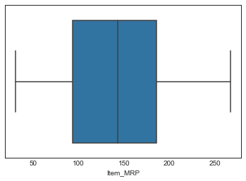

```python
sns.boxplot(x=datafile['Item_MRP'])
```

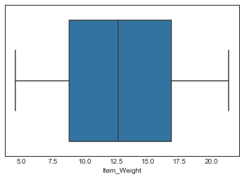

```python
sns.boxplot(x=datafile['Item_Weight'])
```

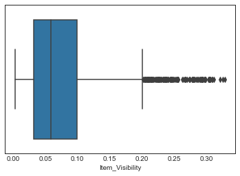

```python
sns.boxplot(x=datafile['Item_Visibility'])
```

Okay only Item_Visibility , seems to have Outliers

There are basically 3 ways with which we can extract the outliers :

1 ) Anything greater or less than 3 standard deviations from the mean is an outlier .

2 ) Keeping the threshold value equal to 3 , z- score is calculated .

3 ) IQR

```python
datafile['Item_Visibility'].describe()
```

```
count    8523.000000
mean        0.070870
std         0.050419
min         0.003575
25%         0.031509
50%         0.058182
75%         0.099119
max         0.328391
Name: Item_Visibility, dtype: float64
```

Method 1 :

```python
print(datafile['Item_Visibility'].describe()[1]  +  3*datafile['Item_Visibility'].describe()[2])
print(datafile['Item_Visibility'].describe()[1]  -  3*datafile['Item_Visibility'].describe()[2])
```

```
0.22212571858415525
-0.08038644635803587
```

```python
datafile['Item_Visibility'].describe()[7]
```

```
0.328390948
```

```python
datafile[datafile['Item_Visibility'] > datafile['Item_Visibility'].describe()[1] + 3*datafile['Item_Visibility'].describe()[2]].index
```

```
Int64Index([  49,   83,  108,  174,  434,  502,  521,  532,  854, 1159, 1272,
            1291, 1311, 1324, 1434, 1454, 1496, 1501, 1560, 1575, 1644, 1651,
            1805, 1827, 1841, 2055, 2088, 2122, 2251, 2324, 2439, 2586, 2613,
            2728, 2855, 2895, 3017, 3206, 3399, 3458, 3474, 3488, 3497, 3540,
            3750, 3767, 3884, 3993, 4006, 4219, 4310, 4382, 4408, 4530, 4656,
            4674, 4789, 4941, 5031, 5150, 5287, 5374, 5732, 5734, 5795, 5837,
            5880, 5891, 5946, 6008, 6012, 6179, 6536, 6576, 6622, 6674, 6786,
            6903, 7005, 7088, 7121, 7215, 7250, 7278, 7388, 7438, 7499, 7549,
            7558, 7603, 7744, 7866, 7949, 8194, 8215, 8273, 8345, 8432],
           dtype='int64')
```

Method 2 :

```python
from scipy import stats
z = np.abs(stats.zscore(datafile['Item_Visibility']))
threshold = 3
print(np.where(z > 3))
```

```
(array([  49,   83,  108,  174,  434,  502,  521,  532,  854, 1159, 1272,
       1291, 1311, 1324, 1434, 1454, 1496, 1501, 1560, 1575, 1644, 1651,
       1805, 1827, 1841, 2055, 2088, 2122, 2251, 2324, 2439, 2586, 2613,
       2728, 2855, 2895, 3017, 3206, 3399, 3458, 3474, 3488, 3497, 3540,
       3750, 3767, 3884, 3993, 4006, 4219, 4310, 4382, 4408, 4530, 4656,
       4674, 4789, 4941, 5031, 5150, 5287, 5374, 5732, 5734, 5795, 5837,
       5880, 5891, 5946, 6008, 6012, 6179, 6536, 6576, 6622, 6674, 6786,
       6903, 7005, 7088, 7121, 7215, 7250, 7278, 7388, 7438, 7499, 7549,
       7558, 7603, 7744, 7866, 7949, 8194, 8215, 8273, 8345, 8432],
      dtype=int64),)
```

Method 3 :

```python
q1 = datafile['Item_Visibility'].quantile(q= 0.15)
q3 = datafile['Item_Visibility'].quantile(q= 0.85)
IQR = q3 - q1
left_bound_min = q1 - 1.5*IQR
right_bound_max = q3 + 1.5*IQR
right_bound_max
```

```
0.2799065748499999
```

```python
datafile[datafile['Item_Visibility'] > right_bound_max].index
```

```
Int64Index([  83,  174,  521,  854, 1805, 2251, 2586, 2613, 2855, 3474, 3488,
            3540, 3750, 4310, 4382, 4674, 4789, 5031, 5150, 5287, 5374, 5732,
            5734, 5880, 6576, 6622, 6674, 7215, 7250, 7388, 7603, 8194, 8273],
           dtype='int64')
```

According to me , the best method to go ahead with is Method 3 . Because , other methods would actually remove some of the helpful Item_VIsibility , that arent really anomalies .

```python
datafile['Item_Visibility'] = datafile['Item_Visibility'].where(datafile['Item_Visibility'] <= 0.2799065748499999,datafile[datafile['Outlet_Type'] == 'Grocery Store']['Item_Visibility'].median())
```

Let us now deal with the skewness , that we observed for Item_Visibility

As of now , we shall be creating a log column for Item_Visibility

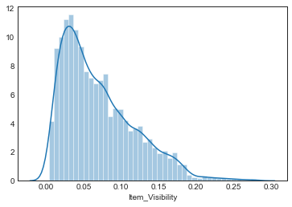

```python
sns.distplot(datafile['Item_Visibility'])
```

```python
datafile['Item_Visibility_Log'] = np.log(datafile['Item_Visibility'])
```

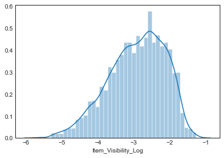

```python
sns.distplot(datafile['Item_Visibility_Log'])
```

```python
datafile.head()
```

|  | Item_Identifier | Item_Weight | Item_Fat_Content | Item_Visibility | Item_Type | Item_MRP | Outlet_Identifier | Outlet_Establishment_Year | Outlet_Size | Outlet_Location_Type | Outlet_Type | Item_Outlet_Sales | Item_Visibility_Log |
| --- | --- | --- | --- | --- | --- | --- | --- | --- | --- | --- | --- | --- | --- |
| 0 | FDA15 | 9.30 | Low Fat | 0.016047 | Dairy | 249.8092 | OUT049 | 1999 | Medium | Tier 1 | Supermarket Type1 | 3735.1380 | -4.132215 |
| 1 | DRC01 | 5.92 | Regular | 0.019278 | Soft Drinks | 48.2692 | OUT018 | 2009 | Medium | Tier 3 | Supermarket Type2 | 443.4228 | -3.948780 |
| 2 | FDN15 | 17.50 | Low Fat | 0.016760 | Meat | 141.6180 | OUT049 | 1999 | Medium | Tier 1 | Supermarket Type1 | 2097.2700 | -4.088756 |
| 3 | FDX07 | 19.20 | Regular | 0.122911 | Fruits and Vegetables | 182.0950 | OUT010 | 1998 | Small | Tier 3 | Grocery Store | 732.3800 | -2.096299 |
| 4 | NCD19 | 8.93 | Low Fat | 0.013217 | Household | 53.8614 | OUT013 | 1987 | High | Tier 3 | Supermarket Type1 | 994.7052 | -4.326277 |

# Feature Engineering

First things first . We notice that Item_Identifier carries some really significant information within its name . And that is . . .

```python
li = []
for i in datafile['Item_Identifier']:
    li.append(i[:2])
arr = np.array(li)
np.unique(arr)
```

```
array(['DR', 'FD', 'NC'], dtype='<U2')
```

The first 2 letters of each Item_Identifier signifies , the following :

DR that stands for Drinks

FD that stands for Foods

Nc that stands for Non Consumables

Now , this means that we shall create a column that holds these 3 categorical values, mentioned above

```python
datafile['Item_Class'] = datafile['Item_Identifier'].str[:2]
```

```python
datafile['Item_Class'].replace(to_replace=['FD','DR','NC'],value = ['Foods','Drinks','Non Consumables'], inplace=True)
```

```python
datafile.head()
```

|  | Item_Identifier | Item_Weight | Item_Fat_Content | Item_Visibility | Item_Type | Item_MRP | Outlet_Identifier | Outlet_Establishment_Year | Outlet_Size | Outlet_Location_Type | Outlet_Type | Item_Outlet_Sales | Item_Visibility_Log | Item_Class |
| --- | --- | --- | --- | --- | --- | --- | --- | --- | --- | --- | --- | --- | --- | --- |
| 0 | FDA15 | 9.30 | Low Fat | 0.016047 | Dairy | 249.8092 | OUT049 | 1999 | Medium | Tier 1 | Supermarket Type1 | 3735.1380 | -4.132215 | Foods |
| 1 | DRC01 | 5.92 | Regular | 0.019278 | Soft Drinks | 48.2692 | OUT018 | 2009 | Medium | Tier 3 | Supermarket Type2 | 443.4228 | -3.948780 | Drinks |
| 2 | FDN15 | 17.50 | Low Fat | 0.016760 | Meat | 141.6180 | OUT049 | 1999 | Medium | Tier 1 | Supermarket Type1 | 2097.2700 | -4.088756 | Foods |
| 3 | FDX07 | 19.20 | Regular | 0.122911 | Fruits and Vegetables | 182.0950 | OUT010 | 1998 | Small | Tier 3 | Grocery Store | 732.3800 | -2.096299 | Foods |
| 4 | NCD19 | 8.93 | Low Fat | 0.013217 | Household | 53.8614 | OUT013 | 1987 | High | Tier 3 | Supermarket Type1 | 994.7052 | -4.326277 | Non Consumables |

Have a look at the fifth row from the top . How come Households , have Low Fat . Is it even possible ?

```python
datafile.loc[datafile['Item_Class']=='Non Consumables','Item_Fat_Content']='No Fat'
```

As of now , we've started to learn some rellay tricky but important aspects of our datasets . This has provided us with an absolutely different angle to look at our dataset

Talking about different perspective , what makes SupermarketType 1 different when compared to SupermarketType 2, or maybe Grocery Store . So , lets have a look at it

```python
pd.crosstab(datafile['Item_Class'],datafile['Outlet_Type'])
```

| Outlet_Type Item_Class | Grocery Store | Supermarket Type1 | Supermarket Type2 | Supermarket Type3 |
| --- | --- | --- | --- | --- |
| Drinks | 99 | 537 | 84 | 79 |
| Foods | 771 | 4001 | 671 | 682 |
| Non Consumables | 213 | 1039 | 173 | 174 |

```python
pd.crosstab(datafile['Outlet_Size'],datafile['Outlet_Type'])
```

| Outlet_Type Outlet_Size | Grocery Store | Supermarket Type1 | Supermarket Type2 | Supermarket Type3 |
| --- | --- | --- | --- | --- |
| High | 0 | 932 | 0 | 0 |
| Medium | 0 | 930 | 928 | 935 |
| Small | 1083 | 3715 | 0 | 0 |

```python
pd.crosstab(datafile['Outlet_Location_Type'],datafile['Outlet_Type'])
```

| Outlet_Type Outlet_Location_Type | Grocery Store | Supermarket Type1 | Supermarket Type2 | Supermarket Type3 |
| --- | --- | --- | --- | --- |
| Tier 1 | 528 | 1860 | 0 | 0 |
| Tier 2 | 0 | 2785 | 0 | 0 |
| Tier 3 | 555 | 932 | 928 | 935 |

As of now , everything leads us to the fact that we must think of Supermarket Type 2 and Supermarket Type3 being one and the same . But , something smells incomplete , Right ? . Lets check it out .

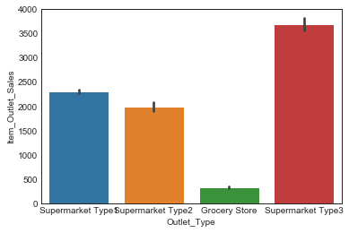

```python
sns.barplot(x='Outlet_Type',data=datafile,y='Item_Outlet_Sales')
```

Alright ! . There is a huge difference in the the Item_Outlet_Sales for Supermarket Type2 and Supermarket Type3 .Does that reject everything that we've proved until now ? We've not yet checked across Outlet_Establishment_Year

```python
pd.crosstab(datafile['Outlet_Establishment_Year'],datafile['Outlet_Type'])
```

| Outlet_Type Outlet_Establishment_Year | Grocery Store | Supermarket Type1 | Supermarket Type2 | Supermarket Type3 |
| --- | --- | --- | --- | --- |
| 1985 | 528 | 0 | 0 | 935 |
| 1987 | 0 | 932 | 0 | 0 |
| 1997 | 0 | 930 | 0 | 0 |
| 1998 | 555 | 0 | 0 | 0 |
| 1999 | 0 | 930 | 0 | 0 |
| 2002 | 0 | 929 | 0 | 0 |
| 2004 | 0 | 930 | 0 | 0 |
| 2007 | 0 | 926 | 0 | 0 |
| 2009 | 0 | 0 | 928 | 0 |

Alright . One of the greatest possibility that comes out of our progress until now is that , Supermarket Type2 and Supermarket Type3 are one and the same . Difference being , Supermarket Type2 are the latest versions of Supermarket Type3

```python
datafile['Outlet_Type'] = datafile['Outlet_Type'].replace(to_replace = 'Supermarket Type3' , value = 'Supermarket Type2')
```

Why is it that Grocery Stores , have such a small Item_Outlet_Sales , in comparison to different Supermarkets ?

```python
for i in datafile['Outlet_Type'].unique():
    print(i,datafile[datafile['Outlet_Type'] == i]['Item_Outlet_Sales'].mean())
```

```
Supermarket Type1 2316.1811481083005
Supermarket Type2 2847.9596786902885
Grocery Store 339.8285004616805
```

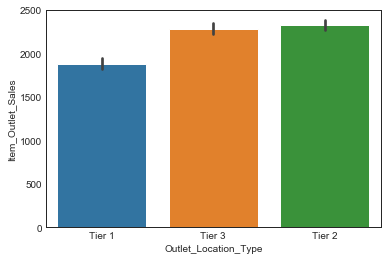

```python
sns.barplot(x='Outlet_Location_Type',y='Item_Outlet_Sales',data=datafile)
```

```python
pd.crosstab(datafile['Outlet_Location_Type'] , datafile['Outlet_Type'])
```

| Outlet_Type Outlet_Location_Type | Grocery Store | Supermarket Type1 | Supermarket Type2 |
| --- | --- | --- | --- |
| Tier 1 | 528 | 1860 | 0 |
| Tier 2 | 0 | 2785 | 0 |
| Tier 3 | 555 | 932 | 1863 |

Opsss ! . The highest grossing Tier : Tier 2 does not accomodate Grocery Store .

Okay , Cool ! We shall come back at this, as and when required

Creating a column named 'Outlet_Existence' that gives an exact number of how old the store is .

```python
datafile['Outlet_Existence'] = [2020-year for year in datafile['Outlet_Establishment_Year']]
```

Creating a column names 'Outlet_Status' . New , if Outlet_Establishment_Year is after 2000 , Old , otherwise

```python
datafile['Outlet_Status'] = ['Old' if year <= 2000 else 'New' for year in datafile['Outlet_Establishment_Year']]
```

```python
datafile.head()
```

|  | Item_Identifier | Item_Weight | Item_Fat_Content | Item_Visibility | Item_Type | Item_MRP | Outlet_Identifier | Outlet_Establishment_Year | Outlet_Size | Outlet_Location_Type | Outlet_Type | Item_Outlet_Sales | Item_Visibility_Log | Item_Class | Outlet_Existence | Outlet_Status |
| --- | --- | --- | --- | --- | --- | --- | --- | --- | --- | --- | --- | --- | --- | --- | --- | --- |
| 0 | FDA15 | 9.30 | Low Fat | 0.016047 | Dairy | 249.8092 | OUT049 | 1999 | Medium | Tier 1 | Supermarket Type1 | 3735.1380 | -4.132215 | Foods | 21 | Old |
| 1 | DRC01 | 5.92 | Regular | 0.019278 | Soft Drinks | 48.2692 | OUT018 | 2009 | Medium | Tier 3 | Supermarket Type2 | 443.4228 | -3.948780 | Drinks | 11 | New |
| 2 | FDN15 | 17.50 | Low Fat | 0.016760 | Meat | 141.6180 | OUT049 | 1999 | Medium | Tier 1 | Supermarket Type1 | 2097.2700 | -4.088756 | Foods | 21 | Old |
| 3 | FDX07 | 19.20 | Regular | 0.122911 | Fruits and Vegetables | 182.0950 | OUT010 | 1998 | Small | Tier 3 | Grocery Store | 732.3800 | -2.096299 | Foods | 22 | Old |
| 4 | NCD19 | 8.93 | No Fat | 0.013217 | Household | 53.8614 | OUT013 | 1987 | High | Tier 3 | Supermarket Type1 | 994.7052 | -4.326277 | Non Consumables | 33 | Old |

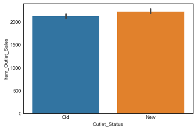

```python
sns.barplot(x='Outlet_Status',y='Item_Outlet_Sales',data=datafile)
```

Although , we notice that Old Outlets have lesser sale than New Outlets , there might be different factors influencing the same

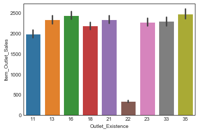

```python
sns.barplot(x='Outlet_Existence',y='Item_Outlet_Sales',data=datafile)
```

Okay . Meaning , there's an Outlet in our datafile that is 22 Years Old ,and is not really generating great sales . Lets Check its background a little more .

As a part of feature engineering , why dont we create a column that helps us differentiate Items that were sold Frequenty or Occasionaly , with regard to each Outlet_Identifier

The following code gives us a basic idea as to what are the frequent Items_Type and what aren't

```python
for i in datafile['Outlet_Identifier'].unique():
    print(i , datafile[datafile['Outlet_Identifier']==i]['Item_Type'].value_counts())
```

```
OUT049 Snack Foods              139
Fruits and Vegetables    138
Household                 95
Frozen Foods              93
Dairy                     78
Canned                    67
Baking Goods              66
Health and Hygiene        52
Meat                      47
Soft Drinks               46
Hard Drinks               30
Breads                    25
Starchy Foods             17
Others                    17
Breakfast                 13
Seafood                    7
Name: Item_Type, dtype: int64
OUT018 Fruits and Vegetables    135
Snack Foods              132
Household                 95
Frozen Foods              92
Canned                    78
Dairy                     73
Baking Goods              68
Health and Hygiene        58
Soft Drinks               46
Meat                      46
Breads                    27
Hard Drinks               22
Others                    20
Starchy Foods             17
Breakfast                 12
Seafood                    7
Name: Item_Type, dtype: int64
OUT010 Fruits and Vegetables    79
Snack Foods              71
Household                67
Frozen Foods             54
Dairy                    43
Baking Goods             42
```

[output cut: 115 more lines]

```
Household                52
Frozen Foods             49
Dairy                    49
Baking Goods             43
Canned                   38
Meat                     32
Health and Hygiene       30
Soft Drinks              26
Others                   17
Breads                   16
Breakfast                10
Hard Drinks               8
Seafood                   6
Starchy Foods             4
Name: Item_Type, dtype: int64
```

```python
list_frequent = ['Dairy',  'Household' , 'Fruits and Vegetables', 'Frozen Foods' ,   'Canned' , 'Snack Foods']
```

```python
list_occasional = [i for i in datafile['Item_Type'].unique() if i not in list_frequent ]
```

```python
for i in list_frequent:
    datafile.loc[datafile['Item_Type'] == i,'Item_Type_Frequency'] = 'Frequent'
```

```python
for i in list_occasional:
    datafile.loc[datafile['Item_Type'] == i,'Item_Type_Frequency'] = 'Occasional'
```

```python
datafile.head()
```

|  | Item_Identifier | Item_Weight | Item_Fat_Content | Item_Visibility | Item_Type | Item_MRP | Outlet_Identifier | Outlet_Establishment_Year | Outlet_Size | Outlet_Location_Type | Outlet_Type | Item_Outlet_Sales | Item_Visibility_Log | Item_Class | Outlet_Existence | Outlet_Status | Item_Type_Frequency |
| --- | --- | --- | --- | --- | --- | --- | --- | --- | --- | --- | --- | --- | --- | --- | --- | --- | --- |
| 0 | FDA15 | 9.30 | Low Fat | 0.016047 | Dairy | 249.8092 | OUT049 | 1999 | Medium | Tier 1 | Supermarket Type1 | 3735.1380 | -4.132215 | Foods | 21 | Old | Frequent |
| 1 | DRC01 | 5.92 | Regular | 0.019278 | Soft Drinks | 48.2692 | OUT018 | 2009 | Medium | Tier 3 | Supermarket Type2 | 443.4228 | -3.948780 | Drinks | 11 | New | Occasional |
| 2 | FDN15 | 17.50 | Low Fat | 0.016760 | Meat | 141.6180 | OUT049 | 1999 | Medium | Tier 1 | Supermarket Type1 | 2097.2700 | -4.088756 | Foods | 21 | Old | Occasional |
| 3 | FDX07 | 19.20 | Regular | 0.122911 | Fruits and Vegetables | 182.0950 | OUT010 | 1998 | Small | Tier 3 | Grocery Store | 732.3800 | -2.096299 | Foods | 22 | Old | Frequent |
| 4 | NCD19 | 8.93 | No Fat | 0.013217 | Household | 53.8614 | OUT013 | 1987 | High | Tier 3 | Supermarket Type1 | 994.7052 | -4.326277 | Non Consumables | 33 | Old | Frequent |

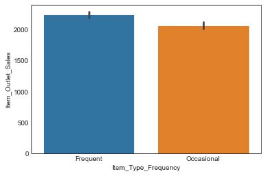

```python
sns.barplot(x='Item_Type_Frequency' ,y='Item_Outlet_Sales',data=datafile)
```

Okay , so practically speaking , anything that is sold frequently , has to generate greater Item_Outlet_Sales

```python
pd.crosstab(datafile['Item_Type_Frequency'],datafile['Outlet_Identifier'])
```

| Outlet_Identifier Item_Type_Frequency | OUT010 | OUT013 | OUT017 | OUT018 | OUT019 | OUT027 | OUT035 | OUT045 | OUT046 | OUT049 |
| --- | --- | --- | --- | --- | --- | --- | --- | --- | --- | --- |
| Frequent | 349 | 607 | 599 | 605 | 336 | 604 | 613 | 599 | 607 | 610 |
| Occasional | 206 | 325 | 327 | 323 | 192 | 331 | 317 | 330 | 323 | 320 |

Okay , so OUT019 AND OUT010 have sold the least amount of Frequent AND Occasional Items. Lets check , in what manner can this help us ?

```python
datafile[datafile['Outlet_Identifier'] == 'OUT019']['Outlet_Type'].unique()
```

```
array(['Grocery Store'], dtype=object)
```

```python
datafile[datafile['Outlet_Identifier'] == 'OUT010']['Outlet_Type'].unique()
```

```
array(['Grocery Store'], dtype=object)
```

Out of the blue , even this helps us prove that Grocery Stores tend to have lower Item_Outlet_Sales

We shall now be calculating calories for each Item in order to create a new column called Item_Calories

The values that we've listed down for every Item_Type , are purely taken from Google :)

```python
def get_calories(data):
    if data['Item_Type'] =='Dairy':
        return 46
    elif data['Item_Type'] =='Soft Drinks':
        return 51
    elif data['Item_Type'] =='Meat':
        return 143
    elif data['Item_Type'] =='Fruits and Vegetables':
        return 65
    elif data['Item_Type'] =='Baking Goods':
        return 140
    elif data['Item_Type'] =='Snack Foods':
        return 475
    elif data['Item_Type'] =='Frozen Foods':
        return 50
    elif data['Item_Type'] =='Breakfast':
        return 350
    elif data['Item_Type'] =='Hard Drinks':
        return 250
    elif data['Item_Type'] =='Canned':
        return 80
    elif data['Item_Type'] =='Starchy Foods':
        return 90
    elif data['Item_Type'] =='Seafood':
        return 204
    elif data['Item_Type'] =='Breads':
        return 250
    else:
        return 0
datafile['Item_Calories'] = ((datafile.apply(get_calories,axis=1))/100)*datafile['Item_Weight']
```

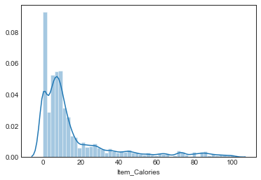

```python
sns.distplot(datafile['Item_Calories'])
```

Uffff.. ! That's right!

That's right skewed . . :))

We shall go ahead with square root his time , because there are items that have Zero calories !

```python
datafile['Item_Calories_Sqrt']=np.sqrt(datafile['Item_Calories'])
```

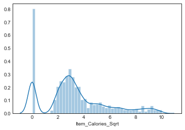

```python
sns.distplot(datafile['Item_Calories_Sqrt'])
```

```python
pd.crosstab(datafile['Item_Class'],datafile['Outlet_Identifier'])
```

| Outlet_Identifier Item_Class | OUT010 | OUT013 | OUT017 | OUT018 | OUT019 | OUT027 | OUT035 | OUT045 | OUT046 | OUT049 |
| --- | --- | --- | --- | --- | --- | --- | --- | --- | --- | --- |
| Drinks | 54 | 87 | 89 | 84 | 45 | 79 | 88 | 93 | 87 | 93 |
| Foods | 387 | 665 | 665 | 671 | 384 | 682 | 674 | 662 | 662 | 673 |
| Non Consumables | 114 | 180 | 172 | 173 | 99 | 174 | 168 | 174 | 181 | 164 |

Most outlet sales are produced by Foods and unfortunately , this Item_Class is minimum in outlet10 and outlet19

```python
datafile[datafile['Outlet_Identifier'] == 'OUT019']['Outlet_Type'].unique()
```

```
array(['Grocery Store'], dtype=object)
```

```python
datafile[datafile['Outlet_Identifier'] == 'OUT010']['Outlet_Type'].unique()
```

```
array(['Grocery Store'], dtype=object)
```

I'm coming for you Grocery Store :)))

We will now be creating bins for 2 of the continuous columns

1 ) Item_Weight

2 ) Item_MRP

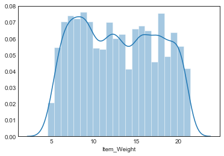

```python
sns.distplot(datafile['Item_Weight'])
```

```python
datafile['Item_Weight'].describe()
```

```
count    8523.000000
mean       12.875418
std         4.645016
min         4.555000
25%         8.785000
50%        12.650000
75%        16.850000
max        21.350000
Name: Item_Weight, dtype: float64
```

```python
datafile['Item_Weight_Bins'] = pd.cut(datafile['Item_Weight'],bins=[ 4.554 , 8.7851 , 12.651 , 16.851 , 21.36],labels=['Extra Light' , 'Light' , 'Heavy' , 'Extra Heavy'])
```

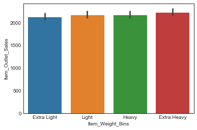

```python
sns.barplot(x='Item_Weight_Bins',y='Item_Outlet_Sales',data=datafile)
```

```python
datafile['Item_MRP'].describe()
```

```
count    8523.000000
mean      140.992782
std        62.275067
min        31.290000
25%        93.826500
50%       143.012800
75%       185.643700
max       266.888400
Name: Item_MRP, dtype: float64
```

```python
datafile['Item_MRP_Bins'] = pd.cut(datafile['Item_MRP'] , bins=[31.28 , 93.82651 , 143.01281 , 185.64371 , 266.88841] , labels= ['Cheap' , 'Average' , 'Above Average' , 'Expensive'])
```

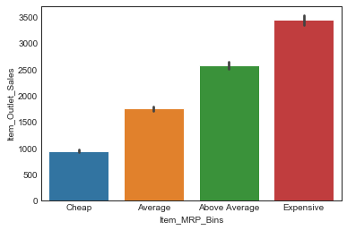

```python
sns.barplot(x='Item_MRP_Bins',y='Item_Outlet_Sales',data=datafile)
```

# Label Encoding and Scaling

Now that we are ready with our dataset , we shall proceed with encoding .

```python
datafile.info()
```

```
<class 'pandas.core.frame.DataFrame'>
RangeIndex: 8523 entries, 0 to 8522
Data columns (total 21 columns):
Item_Identifier              8523 non-null object
Item_Weight                  8523 non-null float64
Item_Fat_Content             8523 non-null object
Item_Visibility              8523 non-null float64
Item_Type                    8523 non-null object
Item_MRP                     8523 non-null float64
Outlet_Identifier            8523 non-null object
Outlet_Establishment_Year    8523 non-null int64
Outlet_Size                  8523 non-null object
Outlet_Location_Type         8523 non-null object
Outlet_Type                  8523 non-null object
Item_Outlet_Sales            8523 non-null float64
Item_Visibility_Log          8523 non-null float64
Item_Class                   8523 non-null object
Outlet_Existence             8523 non-null int64
Outlet_Status                8523 non-null object
Item_Type_Frequency          8523 non-null object
Item_Calories                8523 non-null float64
Item_Calories_Sqrt           8523 non-null float64
Item_Weight_Bins             8523 non-null category
Item_MRP_Bins                8523 non-null category
dtypes: category(2), float64(7), int64(2), object(10)
memory usage: 1.3+ MB
```

First we shall deal with Ordinal Variables :

1 ) Item_Fat_Content

2 ) Outlet_Establishment_Year

3 ) Outlet_Size

4 ) Outlet_Location_Type

5 ) Outlet_Status

6 ) Item_Type_Frequency

7 ) Item_Weight_Bins

8 ) Item_MRP_Bins

9 ) Outlet_Existence

```python
datafile.isnull().sum()
```

```
Item_Identifier              0
Item_Weight                  0
Item_Fat_Content             0
Item_Visibility              0
Item_Type                    0
Item_MRP                     0
Outlet_Identifier            0
Outlet_Establishment_Year    0
Outlet_Size                  0
Outlet_Location_Type         0
Outlet_Type                  0
Item_Outlet_Sales            0
Item_Visibility_Log          0
Item_Class                   0
Outlet_Existence             0
Outlet_Status                0
Item_Type_Frequency          0
Item_Calories                0
Item_Calories_Sqrt           0
Item_Weight_Bins             0
Item_MRP_Bins                0
dtype: int64
```

```python
Ordinal_Dict_Item_Fat_Content = { 'No Fat' : 0 , 'Low Fat' : 1  , 'Regular' : 2 }
datafile['Item_Fat_Content'] = datafile.Item_Fat_Content.map(Ordinal_Dict_Item_Fat_Content)
```

```python
Ordinal_Dict_Outlet_Establishment_Year={1985 : 0 , 1987 : 1 , 1997 : 2 , 1998 : 3, 1999 : 4 , 2002 : 5 , 2004 : 6 ,2007 : 7 , 2009: 8}
datafile['Outlet_Establishment_Year'] = datafile.Outlet_Establishment_Year.map(Ordinal_Dict_Outlet_Establishment_Year)
```

```python
Ordinal_Dict_Outlet_Size = { 'Small' : 0 , 'Medium' : 1 , 'High' : 2 }
datafile['Outlet_Size'] = datafile.Outlet_Size.map(Ordinal_Dict_Outlet_Size)
```

```python
Ordinal_Dict_Outlet_Location_Type  = {'Tier 3' : 0 , 'Tier 2' : 1 , 'Tier 1' : 2}
datafile['Outlet_Location_Type'] = datafile.Outlet_Location_Type.map(Ordinal_Dict_Outlet_Location_Type)
```

```python
Ordinal_Dict_Outlet_Status = { 'Old' : 0 , 'New' : 1 }
datafile['Outlet_Status'] = datafile.Outlet_Status.map(Ordinal_Dict_Outlet_Status)
```

```python
Ordinal_Dict_Item_Type_Frequency =  { 'Occasional' : 0 , 'Frequent' : 1}
datafile['Item_Type_Frequency'] = datafile.Item_Type_Frequency.map(Ordinal_Dict_Item_Type_Frequency)
```

```python
Ordinal_Dict_Item_Weight_Bins ={'Extra Light' : 0  , 'Light' : 1 ,  'Heavy' : 2 , 'Extra Heavy' : 3 }
datafile['Item_Weight_Bins'] = datafile.Item_Weight_Bins.map(Ordinal_Dict_Item_Weight_Bins)
```

```python
Ordinal_Dict_Item_MRP_Bins = { 'Cheap' : 0 , 'Average' : 1 ,  'Above Average' : 2 , 'Expensive' : 3}
datafile['Item_MRP_Bins'] =  datafile.Item_MRP_Bins.map(Ordinal_Dict_Item_MRP_Bins)
```

```python
Ordinal_Dict_Outlet_Existence  = {35 : 0 , 33 : 1, 23 : 2 , 22 : 3, 21 : 4 , 18 : 5 , 16 : 6 , 13 : 7 , 11 : 8}
datafile['Outlet_Existence'] = datafile.Outlet_Existence.map(Ordinal_Dict_Outlet_Existence)
```

Time for nominal variables

```python
from sklearn.preprocessing import LabelEncoder
le=LabelEncoder()
datafile[['Item_Type','Outlet_Type','Item_Class']] = datafile[['Item_Type','Outlet_Type','Item_Class']].apply(le.fit_transform)
```

And we shall now define our X and y

```python
X  =  datafile.drop(columns = ['Item_Outlet_Sales','Item_Identifier','Outlet_Identifier'])
```

```python
y  =  datafile[['Item_Outlet_Sales']]
```

Again , let's move ahead with StandardScaling

```python
from sklearn.preprocessing import StandardScaler
scaler=StandardScaler()
```

```python
from sklearn.model_selection import train_test_split
```

```python
X_train, X_test, y_train, y_test = train_test_split(X, y, test_size=0.2, random_state=31)
```

```python
X_train[['Item_Weight','Item_Visibility','Item_MRP', 'Item_Visibility_Log','Item_Calories', 'Item_Calories_Sqrt']] = scaler.fit_transform(X_train[['Item_Weight','Item_Visibility','Item_MRP', 'Item_Visibility_Log','Item_Calories', 'Item_Calories_Sqrt']])
X_test[['Item_Weight','Item_Visibility','Item_MRP', 'Item_Visibility_Log','Item_Calories', 'Item_Calories_Sqrt']] = scaler.transform(X_test[['Item_Weight','Item_Visibility','Item_MRP', 'Item_Visibility_Log','Item_Calories', 'Item_Calories_Sqrt']])
```

# Dealing with Testing File Only

We shall now deal with testing file, in the same manner as we dealt with our training file . Except , for the fact that we wont remove Outliers , from our testing file ; in order to maintain the integrity of the data .

You might skip the next few cells , until the title 'Finally!!!'

```python
main_testing_datafile=pd.read_csv('test_BigMartSales_AnalyticsVidhya.csv')
main_testing_datafile['Item_Fat_Content']=main_testing_datafile['Item_Fat_Content'].replace(['low fat','LF','reg'],['Low Fat','Low Fat','Regular'])

main_testing_datafile['Outlet_Size'].fillna('Missing',inplace=True)

main_testing_datafile['Item_Weight']=main_testing_datafile['Item_Weight'].fillna(main_testing_datafile.groupby('Item_Identifier')['Item_Weight'].transform('median'))

main_testing_datafile['Item_Weight']=main_testing_datafile['Item_Weight'].fillna(main_testing_datafile.groupby('Item_Type')['Item_Weight'].transform('mean'))

main_testing_datafile['Outlet_Size'].replace(to_replace='Missing',value='Small',inplace=True)

helping_main_testing_datafile=main_testing_datafile.copy()
helping_main_testing_datafile['Outlet_Type']=helping_main_testing_datafile['Outlet_Type'].replace(to_replace=['Supermarket Type1' , 'Supermarket Type2' , 'Supermarket Type3'], value='Supermarket')

only_supermarket_main_testing_datafile=helping_main_testing_datafile.copy()
only_supermarket_main_testing_datafile=only_supermarket_main_testing_datafile[only_supermarket_main_testing_datafile['Outlet_Type']=='Supermarket']
only_supermarket_main_testing_datafile['Item_Visibility'].replace(0,np.nan,inplace=True)
only_supermarket_main_testing_datafile['Item_Visibility']=only_supermarket_main_testing_datafile['Item_Visibility'].fillna(only_supermarket_main_testing_datafile.groupby('Item_Identifier')['Item_Visibility'].transform('mean'))
only_supermarket_main_testing_datafile=only_supermarket_main_testing_datafile['Item_Visibility'].to_frame()

only_grocery_main_testing_datafile=helping_main_testing_datafile.copy()
only_grocery_main_testing_datafile=only_grocery_main_testing_datafile[only_grocery_main_testing_datafile['Outlet_Type']=='Grocery Store']
only_grocery_main_testing_datafile['Item_Visibility'].replace(0,np.nan,inplace=True)
only_grocery_main_testing_datafile['Item_Visibility']=only_grocery_main_testing_datafile['Item_Visibility'].fillna(only_grocery_main_testing_datafile.groupby('Item_Identifier')['Item_Visibility'].transform('mean'))
only_grocery_main_testing_datafile=only_grocery_main_testing_datafile['Item_Visibility'].to_frame()

main_testing_datafile['Item_Visibility'] = only_supermarket_main_testing_datafile['Item_Visibility']

result = pd.concat([main_testing_datafile, only_grocery_main_testing_datafile], axis=1, join='outer')

result.columns=['Item_Identifier', 'Item_Weight', 'Item_Fat_Content', 'Item_Visibility1',
       'Item_Type', 'Item_MRP', 'Outlet_Identifier',
       'Outlet_Establishment_Year', 'Outlet_Size', 'Outlet_Location_Type',
       'Outlet_Type', 'Item_Visibility2']
result.fillna(0,inplace=True)

result['Item_Visibility']=result['Item_Visibility1']+result['Item_Visibility2']

result['Item_Visibility'].replace(0,np.nan,inplace=True)

main_testing_datafile['Item_Visibility']=result['Item_Visibility']
unq=[]
for i in result[result['Item_Visibility'].isnull()]['Item_Identifier']:
    unq.append(main_testing_datafile[main_testing_datafile['Item_Identifier']==i]['Item_Visibility'].mean()+0.1)

fill = pd.DataFrame(index =main_testing_datafile.index[main_testing_datafile.isnull().any(axis=1)], data= unq,columns=['Item_Visibility'])
main_testing_datafile.fillna(fill,inplace=True)

main_testing_datafile[main_testing_datafile['Item_Visibility'].isnull()]

main_testing_datafile[main_testing_datafile['Outlet_Type']=='Grocery Store']['Item_Visibility'].mean()

main_testing_datafile.iloc[4906].fillna(0.11417913043057272,inplace=True)

main_testing_datafile[main_testing_datafile['Outlet_Type']!='Grocery Store']['Item_Visibility'].mean()

main_testing_datafile.fillna(0.06416203204468011,inplace=True)
```

```python
main_testing_datafile['Item_Visibility_Log']=np.log(main_testing_datafile['Item_Visibility'])

li=[]
for i in main_testing_datafile['Item_Identifier']:
    li.append(i[:2])
arr=np.array(li)
np.unique(arr)

main_testing_datafile['Item_Class']=main_testing_datafile['Item_Identifier'].str[:2]

main_testing_datafile['Item_Class'].replace(to_replace=['FD','DR','NC'],value=['Foods','Drinks','Non Consumables'], inplace=True)

main_testing_datafile.loc[main_testing_datafile['Item_Class']=='Non Consumables','Item_Fat_Content']='No Fat'

main_testing_datafile['Outlet_Type']=main_testing_datafile['Outlet_Type'].replace(to_replace='Supermarket Type3',value='Supermarket Type2')

main_testing_datafile['Outlet_Existence'] = [2020-year for year in main_testing_datafile['Outlet_Establishment_Year']]

main_testing_datafile['Outlet_Status'] = ['Old' if year <= 2000 else 'New' for year in main_testing_datafile['Outlet_Establishment_Year']]

list_frequent = ['Dairy',  'Household' , 'Fruits and Vegetables', 'Frozen Foods' ,   'Canned' , 'Snack Foods']

list_occasional = [i for i in main_testing_datafile['Item_Type'].unique() if i not in list_frequent ]

for i in list_frequent:
    main_testing_datafile.loc[main_testing_datafile['Item_Type']==i,'Item_Type_Frequency']='Frequent'

for i in list_occasional:
    main_testing_datafile.loc[main_testing_datafile['Item_Type']==i,'Item_Type_Frequency']='Occasional'

def get_calories(data):
    if data['Item_Type']=='Dairy':
        return 46
    elif data['Item_Type']=='Soft Drinks':
        return 51
    elif data['Item_Type']=='Meat':
        return 143
    elif data['Item_Type']=='Fruits and Vegetables':
        return 65
    elif data['Item_Type']=='Baking Goods':
        return 140
    elif data['Item_Type']=='Snack Foods':
        return 475
    elif data['Item_Type']=='Frozen Foods':
        return 50
    elif data['Item_Type']=='Breakfast':
        return 350
    elif data['Item_Type']=='Hard Drinks':
        return 250
    elif data['Item_Type']=='Canned':
        return 80
    elif data['Item_Type']=='Starchy Foods':
        return 90
    elif data['Item_Type']=='Seafood':
        return 204
    elif data['Item_Type']=='Breads':
        return 250
    else:
        return 0
main_testing_datafile['Item_Calories']=((main_testing_datafile.apply(get_calories,axis=1))/100)*main_testing_datafile['Item_Weight']

main_testing_datafile['Item_Calories_Sqrt']=np.sqrt(main_testing_datafile['Item_Calories'])

main_testing_datafile
main_testing_datafile['Item_Weight_Bins']=pd.cut(main_testing_datafile['Item_Weight'],bins=[4.554,8.631,12.351,16.71,21.36],labels=['Extra Light','Light','Heavy','Extra Heavy'])

main_testing_datafile['Item_MRP_Bins']=pd.cut(main_testing_datafile['Item_MRP'],bins=[31.98,94.413,141.4155,186.0267,266.58841],labels=['Cheap','Average','Above Average','Expensive'])
```

```python
Ordinal_Dict_Item_Fat_Content={'No Fat': 0 , 'Low Fat': 1 , 'Regular':2}
main_testing_datafile['Item_Fat_Content']=main_testing_datafile.Item_Fat_Content.map(Ordinal_Dict_Item_Fat_Content)
Ordinal_Dict_Outlet_Establishment_Year={1985 : 0 , 1987 : 1 , 1997 : 2 , 1998 : 3, 1999 : 4 , 2002 : 5 , 2004 : 6 ,2007 : 7 , 2009: 8}
main_testing_datafile['Outlet_Establishment_Year']=main_testing_datafile.Outlet_Establishment_Year.map(Ordinal_Dict_Outlet_Establishment_Year)
Ordinal_Dict_Outlet_Size = {'Small':0,'Medium':1,'High':2}
main_testing_datafile['Outlet_Size']=main_testing_datafile.Outlet_Size.map(Ordinal_Dict_Outlet_Size)
Ordinal_Dict_Outlet_Location_Type  = {'Tier 3':0,'Tier 2':1,'Tier 1':2}
main_testing_datafile['Outlet_Location_Type']=main_testing_datafile.Outlet_Location_Type.map(Ordinal_Dict_Outlet_Location_Type)
Ordinal_Dict_Outlet_Status= {'Old':0,'New':1}
main_testing_datafile['Outlet_Status']=main_testing_datafile.Outlet_Status.map(Ordinal_Dict_Outlet_Status)
Ordinal_Dict_Item_Type_Frequency= {'Occasional':0,'Frequent':1}
main_testing_datafile['Item_Type_Frequency']=main_testing_datafile.Item_Type_Frequency.map(Ordinal_Dict_Item_Type_Frequency)
Ordinal_Dict_Item_Weight_Bins ={'Extra Light':0 ,'Light':1, 'Heavy':2,'Extra Heavy':3}
main_testing_datafile['Item_Weight_Bins']=main_testing_datafile.Item_Weight_Bins.map(Ordinal_Dict_Item_Weight_Bins)
Ordinal_Dict_Item_MRP_Bins ={'Cheap':0 ,'Average':1, 'Above Average':2,'Expensive':3}
main_testing_datafile['Item_MRP_Bins']=main_testing_datafile.Item_MRP_Bins.map(Ordinal_Dict_Item_MRP_Bins)
Ordinal_Dict_Outlet_Existence ={35:0 , 33:1, 23:2,22:3,21:4,18:5,16:6,13:7,11:8}
main_testing_datafile['Outlet_Existence']=main_testing_datafile.Outlet_Existence.map(Ordinal_Dict_Outlet_Existence)
from sklearn.preprocessing import LabelEncoder
le=LabelEncoder()
main_testing_datafile[['Item_Type','Outlet_Type','Item_Class']] = main_testing_datafile[['Item_Type','Outlet_Type','Item_Class']].apply(le.fit_transform)
main_testing_datafile[['Item_Weight','Item_Visibility','Item_MRP', 'Item_Visibility_Log','Item_Calories', 'Item_Calories_Sqrt']]=scaler.fit_transform(main_testing_datafile[['Item_Weight','Item_Visibility','Item_MRP', 'Item_Visibility_Log','Item_Calories', 'Item_Calories_Sqrt']])
datafile[['Item_Weight','Item_Visibility','Item_MRP', 'Item_Visibility_Log','Item_Calories', 'Item_Calories_Sqrt']]=scaler.fit_transform(datafile[['Item_Weight','Item_Visibility','Item_MRP', 'Item_Visibility_Log','Item_Calories', 'Item_Calories_Sqrt']])
main_testing_datafile_specific_cols=main_testing_datafile[['Item_Identifier','Outlet_Identifier']]
main_testing_datafile.drop(columns=['Item_Identifier','Outlet_Identifier'],inplace=True)
```

# Importing sklearn , mlxtend , Libraries

```python
from sklearn import metrics
from sklearn.model_selection import cross_val_score , GridSearchCV
from sklearn.linear_model import LinearRegression
from sklearn.ensemble import GradientBoostingRegressor , AdaBoostRegressor ,RandomForestRegressor , BaggingRegressor  , StackingRegressor
from sklearn import linear_model
from sklearn.tree import DecisionTreeRegressor
import xgboost as xgb
from mlxtend.feature_selection import SequentialFeatureSelector , ExhaustiveFeatureSelector
from sklearn.feature_selection import RFE
import lightgbm as lgb
```

# Feature Selection

Let us have a look at correlated features first.

```python
correlated_features = set()
correlation_matrix = datafile.drop('Item_Outlet_Sales', axis=1).corr()

for i in range(len(correlation_matrix.columns)):
    for j in range(i):
        if abs(correlation_matrix.iloc[i, j]) > 0.8:
            colname = correlation_matrix.columns[i]
            correlated_features.add(colname)
```

```python
correlated_features
```

```
{'Item_Calories_Sqrt',
 'Item_MRP_Bins',
 'Item_Visibility_Log',
 'Item_Weight_Bins',
 'Outlet_Existence',
 'Outlet_Status'}
```

The features above are the features that have a strong correaltion between each other . This shall help us during feature selection , so that we can try different combinations(by elimination) if at all we spot features that are highly correlated

In the following cells , we've used these selection methods to help us build a list of features;

1 ) Forward Feature Selection ( FFS )

2 ) Backward Feature Elimination ( BFE )

3 ) Recursive Feature Elimination ( RFE )

4 ) Exhaustive Feature Selection ( EFS )

Here are some samples for each of the following

I would be commenting the Codes for feature selection , because they might take some extra time to run and I dont really want you to wait for such a long time .

Number 1 : FFS

```python
# sfs = SequentialFeatureSelector(AdaBoostClassifier(),
#            k_features=5,
#            forward=True,
#            floating=False,
#            scoring='accuracy',
#            cv=None)
# sfs = sfs.fit(X_train, y_train)
# selected_features = X_train.columns[list(sfs.k_feature_idx_)]
# print(selected_features)
```

Number 2 : BFE

```python
# sfs = SequentialFeatureSelector(AdaBoostClassifier(),
#            k_features=5,
#            forward=False,
#            floating=False,
#            scoring='accuracy',
#            cv=None)
# sfs = sfs.fit(X_train, y_train)
# selected_features = X_train.columns[list(sfs.k_feature_idx_)]
# print(selected_features)
```

Number 3 : RFE

```python
# rfe = RFE(estimator=LogisticRegression(),n_features_to_select=5)
# rfe.fit(X_train, y_train)
# X_train.columns[rfe.get_support()]
```

Number 4 : EFS

```python
# efs = ExhaustiveFeatureSelector(AdaBoostClassifier(random_state=31),min_features=4,
#   max_features=5,
# scoring='accuracy',
#        cv=None,n_jobs=-1)
# efs = efs.fit(X_train_temporary, y_train_temporary)
# efs.best_feature_names_
```

With the help of the sample codes above , one can manipulate the parameters inside to get the following List

Making some temporary datafiles that would help us in our following loops

```python
X_train_temporary=X_train.copy()
```

```python
y_train_temporary=y_train.copy()
```

```python
X_test_temporary=X_test.copy()
```

This is the features_list that I've created based on feature selection methods , and my intution :) .

List 1 : All columns

List 2 : FFS

List 3 : BFE

List 4 : Gradient Boosting in RFE excluding Outlet_Establishment_Year

List 5 : Gradient Boosting in RFE excluding Outlet_Existence

List 6 : Gradient Boosting in RFE (using n_features_to_select = 5)

List 7 : Random Forest in RFE (using n_features_to_select = 5)

List 8 : Random Forest in RFE excluding Item_Calories

List 9 : Random Forest in RFE excluding Item_Weight

List 10 : Gradient In EFS

```python
features_list=[

        ['Item_Weight', 'Item_Fat_Content', 'Item_Visibility','Item_Type', 'Item_MRP', 'Outlet_Establishment_Year',
         'Outlet_Size', 'Outlet_Location_Type','Outlet_Type', 'Item_Visibility_Log', 'Item_Class','Outlet_Existence',
         'Outlet_Status', 'Item_Type_Frequency','Item_Calories', 'Item_Calories_Sqrt', 'Item_Weight_Bins','Item_MRP_Bins'],

        ['Item_MRP', 'Outlet_Size', 'Outlet_Location_Type', 'Outlet_Type','Outlet_Status'],

        ['Item_MRP', 'Outlet_Size', 'Outlet_Location_Type', 'Outlet_Type','Item_Visibility'],

        ['Item_MRP','Item_Weight','Outlet_Existence','Outlet_Type','Item_Visibility_Log'],

        ['Item_MRP','Item_Weight','Outlet_Establishment_Year','Outlet_Type','Item_Visibility_Log'],

        ['Item_Weight','Item_Visibility','Item_MRP','Outlet_Establishment_Year','Outlet_Type'],

        ['Item_Weight', 'Item_MRP', 'Outlet_Establishment_Year', 'Outlet_Type','Item_Visibility_Log'],

        ['Item_MRP','Item_Weight','Outlet_Existence','Outlet_Type','Item_Visibility'],

        ['Item_MRP','Item_Calories','Outlet_Existence','Outlet_Type','Item_Visibility'],

        ['Item_Weight','Item_MRP','Outlet_Establishment_Year','Outlet_Type','Item_Visibility_Log','Item_Calories_Sqrt']

            ]
```

Creating a list of all possible models

```python
models_list=['Linear','Lasso','Ridge','Decision Tree','Random Forest','Xg Boost','Ada Boost','Gradient Boost','LightGBM']
```

The following code will go thorugh every combination possible of features_list and models_list and shall give us the best possible list number and model name

```python
row=[]
def get_models(X_train_dataset,y_train_dataset,X_test_dataset):
    for i in features_list:
        for j in models_list:
            if j=='Linear':
                X_train_dataset=X_train_dataset[i]
                X_test_dataset=X_test_dataset[i]
                linreg=LinearRegression()
                linreg.fit(X_train_dataset , y_train_dataset)
                linreg_y_pred = linreg.predict(X_test_dataset)
                row.append([i , j ,np.sqrt(metrics.mean_squared_error(y_test,linreg_y_pred))])
                X_train_dataset=X_train_temporary
                y_train_dataset=y_train_temporary
                X_test_dataset=X_test_temporary
            elif j=='Decision Tree':
                X_train_dataset=X_train_dataset[i]
                X_test_dataset=X_test_dataset[i]
                dtr = DecisionTreeRegressor(random_state=31)
                dtr.fit(X_train_dataset,y_train_dataset)
                dtr_y_pred = dtr.predict(X_test_dataset)
                row.append([i , j ,np.sqrt(metrics.mean_squared_error(y_test,dtr_y_pred))])
                X_train_dataset=X_train_temporary
                y_train_dataset=y_train_temporary
                X_test_dataset=X_test_temporary
            elif j=='Random Forest':
                X_train_dataset=X_train_dataset[i]
                X_test_dataset=X_test_dataset[i]
                rfr = RandomForestRegressor(random_state=31)
                rfr.fit(X_train_dataset,y_train_dataset)
                rfr_y_pred = rfr.predict(X_test_dataset)
                row.append([i , j , np.sqrt(metrics.mean_squared_error(y_test,rfr_y_pred))])
                X_train_dataset=X_train_temporary
                y_train_dataset=y_train_temporary
                X_test_dataset=X_test_temporary
            elif j=='Lasso':
                X_train_dataset=X_train_dataset[i]
                X_test_dataset=X_test_dataset[i]
                las = linear_model.Lasso(alpha=0.1,random_state=31)
                las.fit(X_train,y_train)
                las_y_pred = las.predict(X_test)
                row.append([i , j , np.sqrt(metrics.mean_squared_error(y_test,las_y_pred))])
                X_train_dataset=X_train_temporary
                y_train_dataset=y_train_temporary
                X_test_dataset=X_test_temporary
            elif j=='Ridge':
                X_train_dataset=X_train_dataset[i]
                X_test_dataset=X_test_dataset[i]
                rid = linear_model.Ridge(alpha=0.1,random_state=31)
                rid.fit(X_train_dataset,y_train_dataset)
                rid_y_pred = rid.predict(X_test_dataset)
                row.append([i , j , np.sqrt(metrics.mean_squared_error(y_test,rid_y_pred))])
                X_train_dataset=X_train_temporary
                y_train_dataset=y_train_temporary
                X_test_dataset=X_test_temporary
            elif j=='Xg Boost':
                X_train_dataset=X_train_dataset[i]
                X_test_dataset=X_test_dataset[i]
                xbr = xgb.XGBRegressor(random_state=31)
                xbr.fit(X_train_dataset,y_train_dataset)
                xbr_y_pred = xbr.predict(X_test_dataset)
                row.append([i , j , np.sqrt(metrics.mean_squared_error(y_test,xbr_y_pred))])
                X_train_dataset=X_train_temporary
                y_train_dataset=y_train_temporary
                X_test_dataset=X_test_temporary
            elif j=='Ada Boost':
                X_train_dataset=X_train_dataset[i]
                X_test_dataset=X_test_dataset[i]
                abr = AdaBoostRegressor(random_state=31)
                abr.fit(X_train_dataset,y_train_dataset)
                abr_y_pred = abr.predict(X_test_dataset)
                row.append([i , j , np.sqrt(metrics.mean_squared_error(y_test,abr_y_pred))])
                X_train_dataset=X_train_temporary
                y_train_dataset=y_train_temporary
                X_test_dataset=X_test_temporary
            elif j=='Gradient Boost':
                X_train_dataset=X_train_dataset[i]
                X_test_dataset=X_test_dataset[i]
                gbr = GradientBoostingRegressor(random_state=0)
                gbr.fit(X_train_dataset,y_train_dataset)
                gbr_y_pred = gbr.predict(X_test_dataset)
                row.append([i , j , np.sqrt(metrics.mean_squared_error(y_test,gbr_y_pred))])
                X_train_dataset=X_train_temporary
                y_train_dataset=y_train_temporary
                X_test_dataset=X_test_temporary
            elif j=='LightGBM':
                X_train_dataset=X_train_dataset[i]
                X_test_dataset=X_test_dataset[i]
                gbm = lgb.LGBMRegressor(random_state=0)
                gbm.fit(X_train_dataset,y_train_dataset)
                gbm_y_pred = gbm.predict(X_test_dataset)
                row.append([i , j , np.sqrt(metrics.mean_squared_error(y_test,gbm_y_pred))])
                X_train_dataset=X_train_temporary
                y_train_dataset=y_train_temporary
                X_test_dataset=X_test_temporary
```

Now we are going to use our function get_models ,on our original ( X_train | y_train | X_test | y_test ) datasets

```python
get_models(X_train,y_train,X_test)
```

[output not shown]

[output cut: 17 more lines]

Okay !

So it's time to look at our dataframe that consists of these columns

"Features Combination" - List Type

"Model Type" - Model Name

"Error"

```python
df = pd.DataFrame(row, columns=["Features Combination", "Model Type","Error"])
```

```python
df.sort_values(by=['Error']).head(8)
```

|  | Features Combination | Model Type | Error |
| --- | --- | --- | --- |
| 79 | [Item_MRP, Item_Calories, Outlet_Existence, Ou... | Gradient Boost | 1073.715026 |
| 88 | [Item_Weight, Item_MRP, Outlet_Establishment_Y... | Gradient Boost | 1077.091111 |
| 7 | [Item_Weight, Item_Fat_Content, Item_Visibilit... | Gradient Boost | 1077.183456 |
| 70 | [Item_MRP, Item_Weight, Outlet_Existence, Outl... | Gradient Boost | 1078.280276 |
| 52 | [Item_Weight, Item_Visibility, Item_MRP, Outle... | Gradient Boost | 1078.280276 |
| 43 | [Item_MRP, Item_Weight, Outlet_Establishment_Y... | Gradient Boost | 1078.280276 |
| 34 | [Item_MRP, Item_Weight, Outlet_Existence, Outl... | Gradient Boost | 1078.280276 |
| 61 | [Item_Weight, Item_MRP, Outlet_Establishment_Y... | Gradient Boost | 1078.506698 |

Okay , we notice that mminimum error is given by using combination of List 9

```python
df.iloc[79]['Features Combination']
```

```
['Item_MRP',
 'Item_Calories',
 'Outlet_Existence',
 'Outlet_Type',
 'Item_Visibility']
```

```python
i= df.iloc[79]['Features Combination']
```

I've created temporary files , for X_train and X_test .

These files will be used for further plots and graphs .

```python
tempX_train = X_train[i]
tempX_test= X_test[i]
```

We tried and tested 3 methods :

1 ) Testing different hyperparameters( individual ) inside GradientBoostingRegressor

2 ) Using GridSearchCv on hyperparameters that influence GradientBoostingRegressor, the most

3 ) Bagging with base estimator as GradientBoostingRegressor ,and eventually , trying different bagging hyperparameters on the same

Method 1

Below are the graphs for 6 different hyperparameters of GradientBoostingRegressor

1 ) Learning Rate

2 ) N Estimators

3 ) Max Depth

4 ) Min Samples Leaf

5 ) Min Samples Split

6 ) Max Feature

These graphs will basically help us to look at the training and testing error , at the same time , for each and every hyperparameter

Learning Rate : - Training vs Testing Error

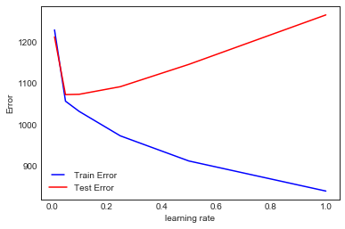

```python
learning_rates = [1, 0.5, 0.25, 0.1, 0.05, 0.01]
train_results = []
test_results = []
for eta in learning_rates:
    model = GradientBoostingRegressor(learning_rate=eta,random_state=0)
    model.fit(tempX_train, y_train)
    train_pred = model.predict(tempX_train)
    error1= np.sqrt(metrics.mean_squared_error(y_train,train_pred))
    train_results.append(error1)
    y_pred = model.predict(tempX_test)
    error2= np.sqrt(metrics.mean_squared_error(y_test,y_pred))
    test_results.append(error2)
from matplotlib.legend_handler import HandlerLine2D
line1, = plt.plot(learning_rates, train_results, 'b', label='Train Error')
line2, = plt.plot(learning_rates, test_results, 'r', label='Test Error')
plt.legend(handler_map={line1: HandlerLine2D(numpoints=2)})
plt.ylabel('Error')
plt.xlabel('learning rate')
plt.show()
```

n_estimators : - Training vs Testing Error

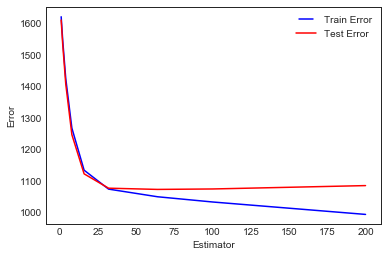

```python
n_estimators = [1, 2, 4, 8, 16, 32, 64, 100, 200]
train_results = []
test_results = []
for estimator in n_estimators:
    model = GradientBoostingRegressor(n_estimators=estimator,random_state=0)
    model.fit(tempX_train, y_train)
    train_pred = model.predict(tempX_train)
    error1= np.sqrt(metrics.mean_squared_error(y_train,train_pred))
    train_results.append(error1)
    y_pred = model.predict(tempX_test)
    error2= np.sqrt(metrics.mean_squared_error(y_test,y_pred))
    test_results.append(error2)
from matplotlib.legend_handler import HandlerLine2D
line1, = plt.plot(n_estimators, train_results, 'b', label='Train Error')
line2, = plt.plot(n_estimators, test_results, 'r', label='Test Error')
plt.legend(handler_map={line1: HandlerLine2D(numpoints=2)})
plt.ylabel('Error')
plt.xlabel('Estimator')
plt.show()
```

max depth : - Training vs Testing Error

[output not shown]

[output cut: 9 more lines]

[output not shown]

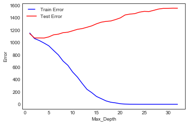

```python
max_depths = np.linspace(1, 32, 32, endpoint=True)
train_results = []
test_results = []
for max_depth in max_depths:
    model = GradientBoostingRegressor(max_depth=max_depth,random_state=0)
    model.fit(tempX_train, y_train)
    train_pred = model.predict(tempX_train)
    error1= np.sqrt(metrics.mean_squared_error(y_train,train_pred))
    train_results.append(error1)
    y_pred = model.predict(tempX_test)
    error2= np.sqrt(metrics.mean_squared_error(y_test,y_pred))
    test_results.append(error2)
from matplotlib.legend_handler import HandlerLine2D
line1, = plt.plot(max_depths, train_results, 'b', label='Train Error')
line2, = plt.plot(max_depths, test_results, 'r', label='Test Error')
plt.legend(handler_map={line1: HandlerLine2D(numpoints=2)})
plt.ylabel('Error')
plt.xlabel('Max_Depth')
plt.show()
```

min_samples_leaf : - Training vs Testing Error

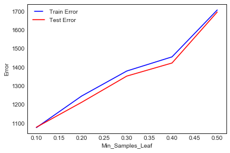

```python
min_samples_leafs = np.linspace(0.1, 0.5, 5, endpoint=True)
train_results = []
test_results = []
for min_samples_leaf in min_samples_leafs:
    model = GradientBoostingRegressor(min_samples_leaf=min_samples_leaf,random_state=0)
    model.fit(tempX_train, y_train)
    train_pred = model.predict(tempX_train)
    error1= np.sqrt(metrics.mean_squared_error(y_train,train_pred))
    train_results.append(error1)
    y_pred = model.predict(tempX_test)
    error2= np.sqrt(metrics.mean_squared_error(y_test,y_pred))
    test_results.append(error2)
from matplotlib.legend_handler import HandlerLine2D
line1, = plt.plot(min_samples_leafs, train_results, 'b', label='Train Error')
line2, = plt.plot(min_samples_leafs, test_results, 'r', label='Test Error')
plt.legend(handler_map={line1: HandlerLine2D(numpoints=2)})
plt.ylabel('Error')
plt.xlabel('Min_Samples_Leaf')
plt.show()
```

min_samples_split : - Training vs Testing Error

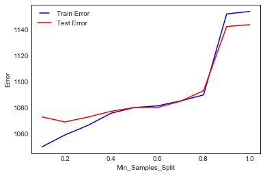

```python
min_samples_splits = np.linspace(0.1, 1.0, 10, endpoint=True)
train_results = []
test_results = []
for min_samples_split in min_samples_splits:
    model = GradientBoostingRegressor(min_samples_split=min_samples_split,random_state=0)
    model.fit(tempX_train, y_train)
    train_pred = model.predict(tempX_train)
    error1= np.sqrt(metrics.mean_squared_error(y_train,train_pred))
    train_results.append(error1)
    y_pred = model.predict(tempX_test)
    error2= np.sqrt(metrics.mean_squared_error(y_test,y_pred))
    test_results.append(error2)
from matplotlib.legend_handler import HandlerLine2D
line1, = plt.plot(min_samples_splits, train_results, 'b', label='Train Error')
line2, = plt.plot(min_samples_splits, test_results, 'r', label='Test Error')
plt.legend(handler_map={line1: HandlerLine2D(numpoints=2)})
plt.ylabel('Error')
plt.xlabel('Min_Samples_Split')
plt.show()
```

Max Features : - Training vs Testing Error

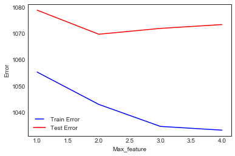

```python
max_features = list(range(1,tempX_train.shape[1]))
train_results = []
test_results = []
for max_feature in max_features:
    model = GradientBoostingRegressor(max_features=max_feature,random_state=0)
    model.fit(tempX_train, y_train)
    train_pred = model.predict(tempX_train)
    error1= np.sqrt(metrics.mean_squared_error(y_train,train_pred))
    train_results.append(error1)
    y_pred = model.predict(tempX_test)
    error2= np.sqrt(metrics.mean_squared_error(y_test,y_pred))
    test_results.append(error2)
from matplotlib.legend_handler import HandlerLine2D
line1, = plt.plot(max_features, train_results, 'b', label='Train Error')
line2, = plt.plot(max_features, test_results, 'r', label='Test Error')
plt.legend(handler_map={line1: HandlerLine2D(numpoints=2)})
plt.ylabel('Error')
plt.xlabel('Max_feature')
plt.show()
```

Looking at the graphs , I've jotted down the utmost adequate values , while considering the bias - variance trade off at the same time

learning_rate=0.05

n_estimators=50

max_depth=2

min_samples_leaf=0.1

min_samples_split=0.23

Unfortunately , after trying different submissions , we did not really get a better score than before

Let's try Method 2

Method 2

The code below is a code for GridSearchCv , to find the best parameter's

I would be commenting the Codes for GridSearchCv, because it might take some extra time to run and I dont really want you to wait for such a long time .

1149.7042623934

```python
# max_features_range=np.arange(1,6,1)
# min_sample_range=[0.1,0.2,0.3,1,2,3,4,5]
# param_grid = {'max_features':max_features_range,'min_samples_leaf':min_sample_range,'max_leaf_nodes':[2,3,4,5,6],'min_samples_split':[0.1,0.2,0.3,0.4],'max_depth':[1,2,3,4]}
# grid=GridSearchCV(GradientBoostingRegressor(),param_grid,cv=None,scoring='neg_mean_squared_error',n_jobs=-1)
# grid.fit(tempX_train,y_train)
# print(grid.best_score_)
# print(grid.best_params_)
```

So , here are the best values for hyperparameters , using GridSearchCv :

random_state=0

max_leaf_nodes= 6

max_features=5

min_samples_leaf=5

Below is the training error when we implement the hyperparameters that we found above

```python
gbr = GradientBoostingRegressor(random_state=0,max_leaf_nodes= 6,max_features=5,min_samples_leaf=5)
gbr.fit(tempX_train,y_train)
training_predictions = gbr.predict(tempX_train)
training_error= np.sqrt(metrics.mean_squared_error(y_train,training_predictions))
training_error
```

```
1042.9883295965958
```

Below is the testing error when we implement the hyperparameters that we found above

```python
testing_predictions = gbr.predict(tempX_test)
testing_error = np.sqrt(metrics.mean_squared_error(y_test,testing_predictions))
testing_error
```

```
1070.3108641628503
```

Also , this gave us a better rank , when we submitted using these Hyperparameters :)

Let us go ahead with Method 3 then

Method 3

A graph for varying training and testing accuracy , when random state changes

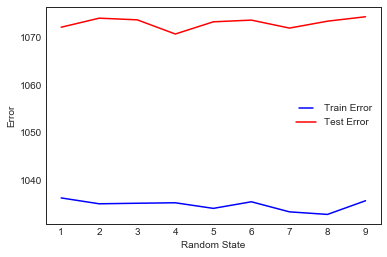

```python
random_states = [i for i in range(1,10)]
train_results = []
test_results = []
for random_state in random_states:
    model = BaggingRegressor(base_estimator=GradientBoostingRegressor(random_state=0),random_state=random_state)
    model.fit(tempX_train, y_train)
    train_pred = model.predict(tempX_train)
    error1= np.sqrt(metrics.mean_squared_error(y_train,train_pred))
    train_results.append(error1)
    y_pred = model.predict(tempX_test)
    error2= np.sqrt(metrics.mean_squared_error(y_test,y_pred))
    test_results.append(error2)
from matplotlib.legend_handler import HandlerLine2D
line1, = plt.plot(random_states, train_results, 'b', label='Train Error')
line2, = plt.plot(random_states, test_results, 'r', label='Test Error')
plt.legend(handler_map={line1: HandlerLine2D(numpoints=2)})
plt.ylabel('Error')
plt.xlabel('Random State')
plt.show()
```

Okay so , looks like the best random state is 4

We are now gonna try different n_estimators over BaggingRegressor

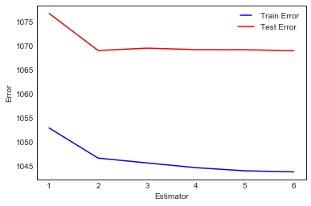

```python
n_estimators = [i for i in range(1,7)]
train_results = []
test_results = []
for estimator in n_estimators:
    model = BaggingRegressor(base_estimator=GradientBoostingRegressor(random_state=0,max_leaf_nodes= 6),n_estimators=estimator,random_state=4)
    model.fit(tempX_train, y_train)
    train_pred = model.predict(tempX_train)
    error1= np.sqrt(metrics.mean_squared_error(y_train,train_pred))
    train_results.append(error1)
    y_pred = model.predict(tempX_test)
    error2= np.sqrt(metrics.mean_squared_error(y_test,y_pred))
    test_results.append(error2)
from matplotlib.legend_handler import HandlerLine2D
line1, = plt.plot(n_estimators, train_results, 'b', label='Train Error')
line2, = plt.plot(n_estimators, test_results, 'r', label='Test Error')
plt.legend(handler_map={line1: HandlerLine2D(numpoints=2)})
plt.ylabel('Error')
plt.xlabel('Estimator')
plt.show()
```

```python
bag = BaggingRegressor(base_estimator=GradientBoostingRegressor(random_state=0),n_estimators=5,random_state=4)
bag.fit(tempX_train,y_train)
training_predictions = bag.predict(tempX_train)
training_error= np.sqrt(metrics.mean_squared_error(y_train,training_predictions))
training_error
```

```
1036.872248283834
```

```python
testing_predictions = bag.predict(tempX_test)
testing_error = np.sqrt(metrics.mean_squared_error(y_test,testing_predictions))
testing_error
```

```
1070.4977977691506
```

Okay , so looks like we are ready with our final model and its hyperpameters:

Model being : BaggingRegressor

base_estimator : GradientBoostingRegressor

GradientBoostingRegressor's random_state : 0

BaggingRegressor's random_state : 4

BaggingRegressor's n_estimators : 5

```python
main_testing_datafile=main_testing_datafile[['Item_MRP',
 'Item_Calories',
 'Outlet_Existence',
 'Outlet_Type',
 'Item_Visibility']]
```

```python
X=datafile.drop(columns=['Item_Identifier','Outlet_Identifier','Item_Outlet_Sales'])
```

```python
y=datafile['Item_Outlet_Sales']
```

```python
X=X[['Item_MRP',
 'Item_Calories',
 'Outlet_Existence',
 'Outlet_Type',
 'Item_Visibility']]
```

# Submission Time

1 ) Instantiating the BaggingRegressor with GradientBoostingRegressor as base_estimator and the set of hyperparameters as mentioned above

2 ) Fitting Our X & y

3 ) And predicting on our main_testing_datafile

```python
bag = BaggingRegressor(base_estimator=GradientBoostingRegressor(random_state=0),n_estimators=5,random_state=4)
bag.fit(X,y)
bag_y_pred = bag.predict(main_testing_datafile)
```

Saving our predictions to datafile called as preddddd

```python
preddddd=pd.DataFrame(bag_y_pred)
```

```python
final_predictions_file=pd.merge(main_testing_datafile_specific_cols,preddddd,how='inner',left_index=True,right_index=True)
```

```python
final_predictions_file.to_csv('C:\\Users\\arham lodha\\Desktop\\BigMartSales_Results.csv')
```

# Thankyou !

We would be grateful , if you could give us some feedback .

Thankyou for taking the time and effort in reading this project :) .

Here, we mark the end of our project .

And by the way, our rank for this project was 123:)

Thankyou , Once again !